# Stage_data analysis

Santiago Holguin Urbano

2025-05-29

## Library importing

```r
library(knitr)
library(readr)
library(lubridate)
library(dplyr)
library(missForest)
library(ggpubr)
```

```r
library(patchwork)
library(ggplot2)
library(ggtext)
library(changepoint)
library(tidyr)
library(car)
library(broom)
library(multcomp)
library(stats)
library(tidyverse)
library(stringr)
library(FactoMineR)
library(factoextra)
library(ggrepel)
library(randomForest)
library(cluster)
library(dendextend)
library(pheatmap)
library(dynamicTreeCut)
library(dbscan)
library(vars)
library(ggraph)
library(igraph)
library(tidygraph)
library(corrplot)
library(vegan)
library(readxl)
library(here)
```

# Data preparation

## Importing data-sets :

- Data–sets most contain headers and be on csv format.
- Maternal cage column name must be “CageID”, maternal cage pup id column name must be “PupID”, adult and juvenile pup’s IDs key columns name must be “id”
- For data merging, maternal cage name is added to the actual id
- actual cage for adult and ado df must be named “cage”

### Importing function and other declarations

```r
import_csv <- function(..., sep = ";", stringsAsFactors = TRUE, header = TRUE, encoding = "UTF-8", convert_empty_to_na = TRUE) {
  path <- here(...)  # Construye la ruta completa

  # Define los valores a tratar como NA solo si se indica
  na_vals <- if (convert_empty_to_na) c("", "NA") else NULL

  read.csv(
    path,
    sep = sep,
    stringsAsFactors = stringsAsFactors,
    header = header,
    fileEncoding = encoding,
    na.strings = na_vals
  )
}

deadPups <- c("C1-3", "C7-1")
ado_data <- FALSE
adult_data <- FALSE
```

### Juvenile data

```r
juvenile_df <- import_csv("pups_data","juvenile","Veave - metadatafile-juvenile-all-full.csv")  # Load juvenile metadata file with semicolon separator

juvenile_df <- juvenile_df %>%
  mutate(
    CageID = trimws(CageID),  # Remove leading/trailing whitespaces
    CageID = sub("(?i)^cage\\s*", "", CageID, perl = TRUE)  # Remove "Cage" prefix
  )

cage_counts <- juvenile_df %>%
  group_by(CageID) %>%
  summarise(n_groups = n_distinct(Condition)) %>%
  filter(n_groups > 1)

# Para los CageID que se repiten en varios Condition, añadir la primera letra de Condition
juvenile_df <- juvenile_df %>%
  mutate(
    CageID = if_else(
      CageID %in% cage_counts$CageID,
      paste0(substr(Condition, 1, 1), "_", CageID),  # Añade la primera letra de Condition
      CageID
    )
  )

juvenile_df <- subset(juvenile_df, Project %in% c("VEAVE"))  # Keep only rows from the VEAVE project

ids_a_eliminar <- deadPups
juvenile_df <- juvenile_df %>%
  filter(!(PupID %in% ids_a_eliminar))

juvenile_df_only <- subset(juvenile_df, Cohort %in% c("Cohort 0", "Cohort 1", "Cohort 2"))  # Filter specific cohorts
```

### Adolescent data

```r
if(ado_data)
  ado_df <- import_csv("pups_data","ado","...")
```

### adult data

```r
if(adult_data)
  adult_df <- import_csv("pups_data","adult","...")
```

### Mapping IDs

```r
if(adult_data || ado_data){
  mapps <- import_csv("pups_data", "...")

# Create a standardized Pup_label per individual, prefixed with "C" only if needed
mapps$Pup_label <- ifelse(
  startsWith(as.character(mapps$maternal_Cage), "C"),
  paste0(mapps$maternal_Cage, "-", mapps$pup_id),
  paste0("C", mapps$maternal_Cage, "-", mapps$pup_id)
)
}

if(ado_data)
  ado_df <- ado_df %>%
  left_join(mapps %>% select(cage, pup_id, Pup_label),
            by = c("cage", "pup_id"))

if(adult_data)
  adult_df <- adult_df %>%
  left_join(mapps %>% select(cage, pup_id, Pup_label),
            by = c("cage", "pup_id"))
```

### Maternal data

```r
days_to_keep <- c(1, 2, 3 ,4, 5, 6, 7 ,8)
days_to_keep <- c(1, 2 ,4, 5, 6)

maternal_df <- import_csv("Resume_df.csv",sep =",")

maternal_df$Transition <- maternal_df$Nest_exits_bouts + maternal_df$Nest_entry_bouts  # Calculate total transitions

maternal_df <- maternal_df %>%
  mutate(Day = floor(Time / 86400) + 1)  # Convert time (in seconds) to day number (1-indexed)

maternal_df <- maternal_df %>%
  filter(Day %in% days_to_keep) # Keep only days 1 to 7

if ("Start_time" %in% colnames(maternal_df)) {
  maternal_df <- maternal_df %>%
    mutate(Start_time = ymd_hms(gsub("T", " ", Start_time))) %>%  # Convert Start_time from ISO format to POSIXct
    filter(!(hour(Start_time) == 7 & minute(Start_time) >= 30 | hour(Start_time) > 7 & hour(Start_time) < 20))
  # Remove daytime (7:30 to 19:59)
}

maternal_full_df <- import_csv("behavioural_annotation.csv", sep=",")  # Load full maternal annotation data

maternal_full_df <- maternal_full_df %>% filter(Cage != "K2")

maternal_full_df <- maternal_full_df %>%
  mutate(Start_time = ymd_hms(gsub("T", " ", Start_time)))  # Convert Start_time to POSIXct format

maternal_full_df$Time <- NA_real_  # Initialize Time column

maternal_full_df <- maternal_full_df %>%
  group_by(Cage) %>%
  mutate(
    start_0 = min(Start_time, na.rm = TRUE),  # Define the starting timestamp per cage
    total_frames = max(frame, na.rm = TRUE),  # Get total number of frames per cage
    Time = as.numeric(difftime(Start_time, start_0, units = "secs")) +  # Compute elapsed time since start
      frame * Recording_duration / total_frames  # Adjust using frame index and recording duration
  ) %>%
  ungroup() %>%
  dplyr::select(-start_0, -total_frames) %>%
  mutate(Day = floor(Time / 86400) + 1)  # Compute the day number from total seconds

maternal_full_df <- maternal_full_df %>%
   filter(Day %in% days_to_keep) %>%
  filter(!(hour(Start_time) == 7 & minute(Start_time) >= 30 | hour(Start_time) > 7 & hour(Start_time) < 20))
 # Remove data from light phase (7:30–19:59)

maternal_df$Group <- as.factor(maternal_df$Group)  # Ensure Group is treated as a factor
```

## Missing data completion

Nonparametric Missing Value Imputation using Random Forest : The function ‘missForest’ in this package is used to impute missing values particularly in the case of mixed-type data. It uses a random forest trained on the observed values of a data matrix to predict the missing values. It can be used to impute continuous and/or categorical data including complex interactions and non-linear relations. It yields an out-of-bag (OOB) imputation error estimate without the need of a test set or elaborate cross-validation. It can be run in parallel to save computation time.

```r
process_missing_data <- function(df, df_name = "df") {
  # Convert character columns to factors
  df[] <- lapply(df, function(col) {
    if (is.character(col)) as.factor(col) else col
  })

  # Calculate and print missing percentages
  missing_pct <- colMeans(is.na(df)) * 100
  missing_df <- data.frame(Column = names(missing_pct), Missing_Percentage = round(missing_pct, 2))
  cat("\n[", df_name, "] Missing data percentages:\n")
  print(kable(missing_df, format = "markdown"))

  # Identify and remove columns with >30% missing data
  to_remove_missing <- names(missing_pct[missing_pct > 30])
  cat("\n[", df_name, "] Columns removed due to >30% missing:\n", to_remove_missing, "\n")
  df_clean <- df[, !(names(df) %in% to_remove_missing)]

  # Check if any columns remain to impute
  if (any(colMeans(is.na(df_clean)) * 100 > 0)) {
    cat("[", df_name, "] Applying missForest imputation...\n")

    # Identify factor columns with too many levels (>53)
    too_many_levels <- sapply(df_clean, function(col) is.factor(col) && nlevels(col) > 53)
    problematic_cols <- names(df_clean)[too_many_levels]

    # Separate problematic columns and data for imputation
    df_problematic <- df_clean[, problematic_cols, drop = FALSE]
    df_for_imputation <- df_clean[, !too_many_levels, drop = FALSE]

    df_for_imputation[] <- lapply(df_for_imputation, function(x) {
    if (is.logical(x)) as.numeric(x) else x
    })
    # Impute missing data with missForest
    imputed_result <- missForest(df_for_imputation)
    df_imputed <- imputed_result$ximp

    # Recombine imputed and problematic columns, preserving original column order
    df_final <- df_clean[, c(names(df_imputed), problematic_cols)]
    df_final[, names(df_imputed)] <- df_imputed
    df_final[, problematic_cols] <- df_problematic
  } else {
    cat("[", df_name, "] No missing data to impute.\n")
    df_final <- df_clean
  }

  return(df_final)
}

# Example: apply on juvenile_df, ado_df, adult_df
juvenile_unic_completed <- process_missing_data(juvenile_df_only, "juvenile_df_only")
```

```
##
## [ juvenile_df_only ] Missing data percentages:
##
##
## |                  |Column            | Missing_Percentage|
## |:-----------------|:-----------------|------------------:|
## |Project           |Project           |               0.00|
## |Cohort            |Cohort            |               0.00|
## |CageID            |CageID            |               0.00|
## |ID.blind          |ID.blind          |               0.00|
## |Condition         |Condition         |               0.00|
## |PupID             |PupID             |               0.00|
## |Sexe              |Sexe              |               0.00|
## |flip.lat.p13      |flip.lat.p13      |              51.52|
## |flip.AUC.p7.10    |flip.AUC.p7.10    |              27.27|
## |av.cliff.lat      |av.cliff.lat      |               6.06|
## |av.geotax.lat     |av.geotax.lat     |               0.00|
## |av.grasp.lat      |av.grasp.lat      |               0.00|
## |norm.av.grasp.lat |norm.av.grasp.lat |               0.00|
## |av.front.lat      |av.front.lat      |              27.27|
## |norm.av.front.lat |norm.av.front.lat |              27.27|
## |d.ear.twicth      |d.ear.twicth      |              27.27|
## |d.ear.c.open      |d.ear.c.open      |              27.27|
## |d.eye.l.open      |d.eye.l.open      |              27.27|
## |d.transition      |d.transition      |              27.27|
## |d.walk            |d.walk            |              27.27|
## |exit.tube         |exit.tube         |               0.00|
## |BW.P3             |BW.P3             |               0.00|
## |BW.P4             |BW.P4             |              27.27|
## |BW.P5             |BW.P5             |              78.79|
## |BW.P6             |BW.P6             |              27.27|
## |BW.P7             |BW.P7             |              27.27|
## |BW.P8             |BW.P8             |              27.27|
## |BW.P9             |BW.P9             |              27.27|
## |BW.P10            |BW.P10            |              27.27|
## |BW.P11            |BW.P11            |              27.27|
## |BW.P12            |BW.P12            |              27.27|
## |BW.P13            |BW.P13            |               0.00|
## |BW.P16            |BW.P16            |              27.27|
## |tot.n.voc.p3      |tot.n.voc.p3      |               0.00|
```

[output cut: 9 more lines]

```
## |DGKH              |DGKH              |               6.06|
## |FKBP5             |FKBP5             |               3.03|
## |HSP90AA1          |HSP90AA1          |               3.03|
## |HSP90AB1          |HSP90AB1          |               3.03|
## |NFATC1            |NFATC1            |               3.03|
## |NR3C1             |NR3C1             |               3.03|
## |PTGES3            |PTGES3            |               3.03|
## |SGK1              |SGK1              |               3.03|
## |SGK3              |SGK3              |               3.03|
## |SKA2              |SKA2              |               3.03|
## |STAT5A            |STAT5A            |               3.03|
##
## [ juvenile_df_only ] Columns removed due to >30% missing:
##  flip.lat.p13 BW.P5 av.freq.p14 av.ep.dur.p14 lat.p14 Cortp
## [ juvenile_df_only ] Applying missForest imputation...
```

[output not shown]

```r
juvenile_all_completed <- process_missing_data(juvenile_df, "juvenile_df")
```

```
##
## [ juvenile_df ] Missing data percentages:
##
##
## |                  |Column            | Missing_Percentage|
## |:-----------------|:-----------------|------------------:|
## |Project           |Project           |               0.00|
## |Cohort            |Cohort            |               0.00|
## |CageID            |CageID            |               0.00|
## |ID.blind          |ID.blind          |               0.00|
## |Condition         |Condition         |               0.00|
## |PupID             |PupID             |               0.00|
## |Sexe              |Sexe              |               0.00|
## |flip.lat.p13      |flip.lat.p13      |              23.08|
## |flip.AUC.p7.10    |flip.AUC.p7.10    |              11.54|
## |av.cliff.lat      |av.cliff.lat      |               3.85|
## |av.geotax.lat     |av.geotax.lat     |               2.56|
## |av.grasp.lat      |av.grasp.lat      |               1.28|
## |norm.av.grasp.lat |norm.av.grasp.lat |               1.28|
## |av.front.lat      |av.front.lat      |              12.82|
## |norm.av.front.lat |norm.av.front.lat |              12.82|
## |d.ear.twicth      |d.ear.twicth      |              11.54|
## |d.ear.c.open      |d.ear.c.open      |              11.54|
## |d.eye.l.open      |d.eye.l.open      |              25.64|
## |d.transition      |d.transition      |              16.67|
## |d.walk            |d.walk            |              25.64|
## |exit.tube         |exit.tube         |              57.69|
## |BW.P3             |BW.P3             |              57.69|
## |BW.P4             |BW.P4             |              11.54|
## |BW.P5             |BW.P5             |              33.33|
## |BW.P6             |BW.P6             |              11.54|
## |BW.P7             |BW.P7             |              11.54|
## |BW.P8             |BW.P8             |              11.54|
## |BW.P9             |BW.P9             |              11.54|
## |BW.P10            |BW.P10            |              11.54|
## |BW.P11            |BW.P11            |              11.54|
## |BW.P12            |BW.P12            |              11.54|
## |BW.P13            |BW.P13            |               1.28|
## |BW.P16            |BW.P16            |              43.59|
## |tot.n.voc.p3      |tot.n.voc.p3      |               0.00|
```

[output cut: 9 more lines]

```
## |DGKH              |DGKH              |              60.26|
## |FKBP5             |FKBP5             |              58.97|
## |HSP90AA1          |HSP90AA1          |              58.97|
## |HSP90AB1          |HSP90AB1          |              58.97|
## |NFATC1            |NFATC1            |              58.97|
## |NR3C1             |NR3C1             |              58.97|
## |PTGES3            |PTGES3            |              58.97|
## |SGK1              |SGK1              |              58.97|
## |SGK3              |SGK3              |              58.97|
## |SKA2              |SKA2              |              58.97|
## |STAT5A            |STAT5A            |              58.97|
##
## [ juvenile_df ] Columns removed due to >30% missing:
##  exit.tube BW.P3 BW.P5 BW.P16 Cortp CDK9 DGKH FKBP5 HSP90AA1 HSP90AB1 NFATC1 NR3C1 PTGES3 SGK1 SGK3 SKA2 STAT5A
## [ juvenile_df ] Applying missForest imputation...
```

[output not shown]

[output cut: 50 more lines]

[output not shown]

```r
if(ado_data)
  ado_all_completed      <- process_missing_data(ado_df, "ado_df")

if(adult_data)
  adult_all_completed    <- process_missing_data(adult_df, "adult_df")
```

# Functions creation

## Maternal analysis

### CONT vs LBN box-plot

```r
plot_behavior_boxplot <- function(df, title, y_label, base_colors, value_column) {
  # Count individuals per group
  group_counts <- df %>%
    group_by(Group) %>%
    summarise(n = n(), .groups = "drop")

  # Create enriched group labels with n
  df <- df %>%
    mutate(Group_n = paste0(Group, " (n = ", group_counts$n[match(Group, group_counts$Group)], ")")) %>%
    mutate(Group_n = factor(Group_n, levels = unique(Group_n)))

  # Generate color mapping with enriched labels
  colors <- setNames(base_colors[as.character(group_counts$Group)],
                     paste0(group_counts$Group, " (n = ", group_counts$n, ")"))

  # Compute y-axis limits
  ymin <- min(df[[value_column]], na.rm = TRUE)
  ymax <- max(df[[value_column]], na.rm = TRUE)
  range <- ymax - ymin
  padding <- range / 2

  lower_limit <- max(0, ymin - padding)
  upper_limit <- ymax + padding

  comparisons <- list(levels(df$Group_n))

  # Plot
  p <- ggplot(df, aes(x = Group_n, y = .data[[value_column]], fill = Group_n)) +
    geom_boxplot(outlier.shape = NA) +
    geom_jitter(
      shape = 21,
      size = 2,
      stroke = 0.3,
      color = "black",
      position = position_jitter(width = 0.15)
    ) +
    stat_compare_means(
      comparisons = comparisons,
      method = "wilcox.test",
      label = "p",
      label.y = upper_limit,
      bracket.size = 0.8,
      tip.length = 0.02
    ) +
    labs(
      title = title,
      y = y_label,
      x = "Group",
      fill = "Groups :"
    ) +
    scale_y_continuous(limits = c(lower_limit, upper_limit + range * 0.1)) +
    scale_fill_manual(values = colors) +
    theme_minimal() +
    theme(panel.grid = element_blank())

  return(p)
}
```

### CONT vs LBN day by day evolution box-plots

```r
plot_duration_ratio_with_wilcox <- function(df, y_var, title, y_label, colors) {
  y_var_sym <- sym(y_var)

  # 1. Wilcoxon test between consecutive days
  wilcox_consecutive_days <- function(subdf) {
    jours <- sort(unique(subdf$Day))
    results <- data.frame(Day1 = integer(), Day2 = integer(), p_value = numeric(), stringsAsFactors = FALSE)

    for (i in seq_along(jours)[-length(jours)]) {
      d1 <- jours[i]
      d2 <- jours[i + 1]
      vals1 <- subdf %>% filter(Day == d1) %>% pull(!!y_var_sym)
      vals2 <- subdf %>% filter(Day == d2) %>% pull(!!y_var_sym)

      p_val <- if (length(vals1) > 0 & length(vals2) > 0) {
        wilcox.test(vals1, vals2, paired = FALSE)$p.value
      } else {
        NA
      }

      results <- rbind(results, data.frame(Day1 = d1, Day2 = d2, p_value = p_val))
    }
    return(results)
  }

  # 2. Wilcoxon results per group
  results_all <- bind_rows(
    df %>% filter(Group == "LBN") %>% wilcox_consecutive_days() %>% mutate(Group = "LBN"),
    df %>% filter(Group == "CONT") %>% wilcox_consecutive_days() %>% mutate(Group = "CONT")
  ) %>%
    filter(!is.na(p_value)) %>%
    mutate(xstart = Day1, xend = Day2)

  # 3. Combine results across groups
  y_vals <- pull(df, !!y_var_sym)
  joint_results <- results_all %>%
    group_by(Day1, Day2) %>%
    summarise(
      xstart = first(xstart),
      xend = first(xend),
      p_LBN = first(p_value[Group == "LBN"]),
      p_CONT = first(p_value[Group == "CONT"]),
      .groups = "drop"
    ) %>%
    mutate(
      y = max(y_vals, na.rm = TRUE) + 0.03 * diff(range(y_vals, na.rm = TRUE)),
      label = paste0(
        "<span style='color:", colors["LBN"], ";'>p(LBN) = ", signif(p_LBN, 3), "</span><br>",
        "<span style='color:", colors["CONT"], ";'>p(CONT) = ", signif(p_CONT, 3), "</span>"
      )
    )

  # 4. Y-axis limits
  ymin <- min(y_vals, na.rm = TRUE)
  ymax <- max(y_vals, na.rm = TRUE)
  range_val <- ymax - ymin
  lower_limit <- max(0, ymin - range_val / 2)
  upper_limit <- ymax + range_val / 2 + 0.2 * range_val

  # 5. ANOVA
  df_for_aov <- df %>% mutate(y_temp = !!y_var_sym)
  p_anova <- summary(aov(y_temp ~ Group, data = df_for_aov))[[1]][["Pr(>F)"]][1]

  # 6. Group labels
  group_counts <- df %>% group_by(Group) %>% summarise(n = n(), .groups = "drop")
  df <- df %>%
    mutate(Group_n = paste0(Group, " (n = ", group_counts$n[match(Group, group_counts$Group)], ")")) %>%
    mutate(Group_n = factor(Group_n, levels = unique(Group_n)))
  colors_named <- setNames(
    colors[as.character(group_counts$Group)],
    paste0(group_counts$Group, " (n = ", group_counts$n, ")")
  )

  # 7. Plot
  p <- ggplot(df, aes(x = factor(Day), y = !!y_var_sym, fill = Group_n)) +
    geom_boxplot(position = position_dodge(0.8), alpha = 0.6, width = 0.6, outlier.shape = NA) +
    geom_jitter(
      shape = 21,
      size = 2,
      stroke = 0.3,
      color = "black",
      position = position_jitterdodge(jitter.width = 0.15, dodge.width = 0.8)
    ) +
    scale_fill_manual(values = colors_named) +
    coord_cartesian(ylim = c(lower_limit - 0.2 * range_val, upper_limit)) +
    labs(
      title = paste0(title, "\nGlobal ANOVA: p = ", signif(p_anova, 3)),
      x = "Day",
      y = y_label
    ) +
    theme_minimal(base_size = 12) +
    theme(panel.grid = element_blank(), legend.position = "bottom")

  # 8. Add p-value annotations
  p <- p +
    geom_segment(data = joint_results,
                 aes(x = xstart + 0.1, xend = xend - 0.1, y = y, yend = y),
                 inherit.aes = FALSE, size = 0.5) +
    geom_segment(data = joint_results,
                 aes(x = xstart + 0.1, xend = xstart + 0.1, y = y - 0.02 * range_val, yend = y),
                 inherit.aes = FALSE, size = 0.5) +
    geom_segment(data = joint_results,
                 aes(x = xend - 0.1, xend = xend - 0.1, y = y - 0.02 * range_val, yend = y),
                 inherit.aes = FALSE, size = 0.5) +
    ggtext::geom_richtext(data = joint_results,
                          aes(x = (xstart + xend)/2, y = y + 0.15 * range_val, label = label),
                          fill = NA, label.color = NA, size = 3, inherit.aes = FALSE)

  return(p)
}
```

### PCA

```r
analyser_clusters_pca_mat <- function(df_all_corrected, vars_interes, nombreDimensions = 2, k = 3) {

  # Vérifications des colonnes nécessaires
  required_cols <- c("Cage.ID", "Group")
  missing_cols <- setdiff(required_cols, colnames(df_all_corrected))
  if (length(missing_cols) > 0) {
    stop(paste("Colonnes manquantes :", paste(missing_cols, collapse = ", ")))
  }

  # Vérification que les vars_interes existent
  vars_interes <- intersect(vars_interes, colnames(df_all_corrected))
  if (length(vars_interes) == 0) {
    stop("Aucune variable d'intérêt trouvée dans le dataframe.")
  }

  df_all_corrected <- df_all_corrected %>%
    mutate(Cage.ID = as.factor(Cage.ID)) %>%
    dplyr::select(Cage.ID, Group, all_of(vars_interes)) %>%
    na.omit()

  # Sélection des variables numériques
  df_numeric <- df_all_corrected %>%
    dplyr::select(where(is.numeric), -Cage.ID)

  # Suppression des colonnes avec variance nulle
  variance_zero <- sapply(df_numeric, function(x) var(x) == 0)
  if (any(variance_zero)) {
    cat("Colonnes avec variance nulle supprimées :", names(variance_zero)[variance_zero], "\n")
    df_numeric <- df_numeric[, !variance_zero, drop = FALSE]
  }

  if (ncol(df_numeric) < nombreDimensions) {
    stop("Pas assez de variables numériques pour réaliser la PCA avec ", nombreDimensions, " dimensions.")
  }

  # PCA
  pca_res <- FactoMineR::PCA(df_numeric, scale.unit = TRUE, graph = FALSE)

  # Biplot (facultatif)
  print(factoextra::fviz_pca_biplot(pca_res,
                                    label = "var",
                                    habillage = df_all_corrected$Cage.ID,
                                    addEllipses = FALSE,
                                    repel = TRUE,
                                    geom.ind = "point"))

  # Scores PCA
  df_scores <- as.data.frame(pca_res$ind$coord[, 1:nombreDimensions])
  colnames(df_scores) <- paste0("Dim.", 1:nombreDimensions)
  df_scores$Cage.ID <- df_all_corrected$Cage.ID

  # Clustering hiérarchique
  hc <- hclust(dist(df_scores[, 1:nombreDimensions]), method = "ward.D2")
  plot(hc, main = "Dendrogramme clustering sur composantes principales")

  # Clustering dynamique ou k fixe
  if (k == -1) {
    diss_matrix <- as.matrix(dist(df_scores[, 1:nombreDimensions]))
    clusters <- cutreeDynamic(dendro = hc, distM = diss_matrix, method = "tree", deepSplit = 2)
    message("Clustering automatique avec cutreeDynamic()")
  } else {
    clusters <- cutree(hc, k = k)
    message(paste("Clustering avec k =", k))
  }

  dend <- as.dendrogram(hc)
  ordered_clusters <- clusters[order.dendrogram(dend)]

  cluster_colors <- RColorBrewer::brewer.pal(max(3, length(unique(clusters))), "Set2")
  cluster_color_map <- setNames(cluster_colors, sort(unique(clusters)))
  branch_colors <- cluster_color_map[as.character(ordered_clusters)]

  dend <- color_branches(dend, k = length(unique(clusters)), col = cluster_colors)
  dend <- set(dend, "branches_lwd", 3)
  dend <- set(dend, "labels", as.character(ordered_clusters))
  dend <- set(dend, "labels_col", branch_colors)
  dend <- set(dend, "labels_cex", 1.2)

  plot(dend, main = "Dendrogramme avec couleurs et étiquettes de cluster")
  legend("topright", legend = paste("Cluster", sort(unique(clusters))),
         fill = cluster_colors, border = NA, bty = "n")

  # Ajouter cluster
  df_scores$cluster <- factor(clusters)

  # Ajout du groupe
  df_scores <- df_scores %>%
    left_join(df_all_corrected %>% distinct(Cage.ID, Group), by = "Cage.ID")

  # Plot des clusters sur PCA
  p_cluster <- ggplot(df_scores, aes(x = Dim.1, y = Dim.2, color = cluster, shape = Group)) +
    geom_point(size = 3, alpha = 0.8) +
    geom_text_repel(aes(label = Cage.ID), size = 3) +
    scale_shape_manual(values = c("LBN" = 16, "CONT" = 15)) +
    labs(title = "Clusters sur composantes principales",
         color = "Cluster",
         shape = "Group") +
    theme_minimal() +
    theme(panel.grid = element_blank())
  print(p_cluster)

  # Proportions par cage
  proportions <- df_scores %>%
    group_by(Cage.ID, cluster) %>%
    summarise(nb_obs = n(), .groups = 'drop') %>%
    group_by(Cage.ID) %>%
    mutate(
      total_obs = sum(nb_obs),
      prop_cluster = nb_obs / total_obs
    ) %>%
    arrange(Cage.ID, desc(prop_cluster)) %>%
    left_join(df_scores %>% distinct(Cage.ID, Group), by = "Cage.ID")

  dominant_clusters <- proportions %>%
    slice_max(prop_cluster, n = 1) %>%
    arrange(cluster, desc(prop_cluster))

  print(dominant_clusters, n = 100)

  return(list(
    pca = pca_res,
    clusters = df_scores,
    proportions = dominant_clusters
  ))
}
```

### Random forest

```r
cluster_rf_analysis_mat <- function(data_df,
                                    k = NULL,             # Nombre de clusters (NULL = auto)
                                    deepSplit = 2,        # Pour cutreeDynamic
                                    plot_heatmap = TRUE) {

  # Étape 1 : Ajouter un identifiant de ligne pour suivi
  data_df <- data_df %>%
    mutate(row_id = row_number())

  # Étape 2 : Extraire les métadonnées (Cage.ID, Group) + row_id
  meta <- data_df %>%
    dplyr::select(Cage.ID, Group, row_id)

  # Étape 3 : Extraire données numériques avec row_id
  numeric_data <- data_df %>%
    dplyr::select(row_id, where(is.numeric))

  # Étape 4 : Joindre les métadonnées aux données numériques
  data <- inner_join(numeric_data, meta, by = "row_id") %>%
    dplyr::select(-row_id) %>%
    na.omit()

  # Étape 5 : Vérification du nombre d’observations
  if (nrow(data) < 3) {
    stop("Pas assez de données après suppression des NA pour effectuer l’analyse.")
  }

  # Étape 6 : Suppression des colonnes à variance nulle
  numeric_data <- data %>% dplyr::select(where(is.numeric))
  zero_var_cols <- sapply(numeric_data, function(x) var(x, na.rm = TRUE) == 0)
  if (any(zero_var_cols)) {
    cat("Colonnes à variance nulle supprimées :", names(zero_var_cols)[zero_var_cols], "\n")
    numeric_data <- numeric_data[, !zero_var_cols]
  }

  # Étape 7 : Random Forest non supervisé
  rf_model <- randomForest(x = numeric_data, proximity = TRUE, ntree = 500)

  # Matrice de dissimilarité propre
  prox <- rf_model$proximity
  diss_matrix <- 1 - prox

  # S'assurer qu'elle est symétrique et diagonale = 0
  diss_matrix[lower.tri(diss_matrix)] <- t(diss_matrix)[lower.tri(diss_matrix)]
  diag(diss_matrix) <- 0

  # Vérification finale
  if (any(!is.finite(diss_matrix))) stop("Dissimilarity matrix has NA/NaN/Inf")
  if (!isSymmetric(diss_matrix)) stop("Dissimilarity matrix is not symmetric")


  print(dim(rf_model$proximity))
  print(sum(is.na(rf_model$proximity)))
  print(summary(as.vector(rf_model$proximity)))


  # Étape 9 : Clustering hiérarchique
  hc <- hclust(as.dist(diss_matrix), method = "ward.D2")

  # Étape 10 : Découpage en clusters
  if (is.null(k)) {
    clusters <- cutreeDynamic(dendro = hc, distM = diss_matrix, method = "tree", deepSplit = deepSplit)
  } else {
    clusters <- cutree(hc, k = k)
  }

  # Étape 11 : Dendrogramme
  dend <- as.dendrogram(hc)
  dend <- color_branches(dend, k = length(unique(clusters)))
  dend <- set(dend, "branches_lwd", 2)
  plot(dend, main = "Dendrogramme Random Forest")

  # Étape 12 : PCA + visualisation
  pca <- prcomp(numeric_data, scale. = TRUE)
  pca_df <- as.data.frame(pca$x[, 1:2])
  colnames(pca_df) <- c("PC1", "PC2")
  pca_df$cluster <- as.factor(clusters)
  pca_df$CageID <- data$CageID
  pca_df$Group <- data$Group

  p <- ggplot(pca_df, aes(x = PC1, y = PC2, color = cluster, shape = Group)) +
    geom_point(size = 3, alpha = 0.8) +
    geom_text_repel(aes(label = CageID), size = 3) +
    labs(title = "Clusters via Random Forest + PCA") +
    theme_minimal()
  print(p)

  # Étape 13 : Résumé par cage
  df_scores <- pca_df %>%
    dplyr::select(CageID, Group, cluster)

  proportions <- df_scores %>%
    group_by(CageID, cluster) %>%
    summarise(nb_obs = n(), .groups = 'drop') %>%
    group_by(CageID) %>%
    mutate(
      total_obs = sum(nb_obs),
      prop_cluster = nb_obs / total_obs
    ) %>%
    arrange(CageID, desc(prop_cluster)) %>%
    left_join(df_scores %>% distinct(CageID, Group), by = "CageID")

  dominant_clusters <- proportions %>%
    slice_max(prop_cluster, n = 1) %>%
    arrange(cluster, desc(prop_cluster))
  print(dominant_clusters, n = 100)

  # Étape 14 : Heatmap
  if (plot_heatmap) {
    df <- data_df %>%
      dplyr::select(CageID, Group, where(is.numeric)) %>%
      na.omit()

    df_cage_mean <- df %>%
    group_by(CageID, Group) %>%
    summarise(across(where(is.numeric), mean, na.rm = TRUE), .groups = "drop")

  if(any(duplicated(df_cage_mean$CageID))){
    stop("CageID contiene valores duplicados. Por favor, revisa los datos.")
  }

  mat_scaled <- df_cage_mean %>%
    column_to_rownames("CageID") %>%
    dplyr::select(-Group) %>%
    scale()

    annotation <- df_cage_mean %>%
      dplyr::select(CageID, Group) %>%
      column_to_rownames("CageID")

    pheatmap(t(mat_scaled),
         cluster_rows = TRUE,
         cluster_cols = TRUE,
         annotation_col = annotation,
         annotation_colors = list(Group = c("LBN" = "#E69F00", "CONT" = "#56B4E9")),
         main = "Expression moyenne par cage (variables en colonnes)",
         fontsize_col = 10)
  }

  return(list(
    rf_model = rf_model,
    diss_matrix = diss_matrix,
    hc = hc,
    clusters = clusters,
    pca_df = pca_df,
    dominant_clusters = dominant_clusters
  ))
}
```

## Pup’s analysis

### CONT vs LBN Box-plot

```r
plot_variable_box <- function(df, df_condition, var_name, fill_colors, y_label) {
  # Convert var_name to symbol for tidy evaluation
  var_sym <- sym(var_name)

  # 1. Filter relevant data
  df_stat <- df %>%
    filter(Condition %in% names(fill_colors)) %>%
    dplyr::select(Condition, !!var_sym, CageID) %>%
    filter(!is.na(!!var_sym))

  # 2. Get adjusted p-value
  p_val <- df_condition %>%
    filter(Variable == var_name, Modele == "Modèle_1") %>%
    pull(P_adj_global)%>%
    first()

  # 3. Format p-value for display
  p_label <- paste0("p = ", formatC(p_val, format = "e", digits = 2))

  # 4. Define y-axis limits and annotation positions
  upper_limit <- max(pull(df_stat, !!var_sym), na.rm = TRUE) * 1.2
  lower_limit <- min(pull(df_stat, !!var_sym), na.rm = TRUE) * 0.8
  ylim_max <- upper_limit * 1.2
  bracket_y <- upper_limit * 1.1
  text_y <- upper_limit * 1.13

  # 5. Generate plot
  p <- ggplot(df_stat, aes(x = Condition, y = !!var_sym, fill = Condition)) +
    geom_boxplot(outlier.shape = NA, width = 0.5) +
    geom_jitter(size = 2, width = 0.15, shape = 21, stroke = 0.3, color = "black") +

    # Bracket
    geom_segment(aes(x = 1, xend = 2, y = bracket_y, yend = bracket_y), size = 0.8) +
    geom_segment(aes(x = 1, xend = 1, y = bracket_y * 0.98, yend = bracket_y), size = 0.8) +
    geom_segment(aes(x = 2, xend = 2, y = bracket_y * 0.98, yend = bracket_y), size = 0.8) +

    # P-value annotation
    annotate("label",
             x = 1.5, y = text_y,
             label = p_label, size = 5,
             fill = "white", alpha = 0.8, label.size = NA) +

    scale_fill_manual(values = fill_colors) +
    scale_y_continuous(limits = c(lower_limit, ylim_max)) +
    labs(
      title = var_name,
      x = "Group",
      y = y_label,
      fill = "Group"
    ) +
    theme_minimal() +
    theme(panel.grid = element_blank())

  return(p)
}
```

### PCA- pups

```r
analyser_clusters_pca <- function(df_all_corrected, vars_interes, nombreDimensions = 2, k = 3) {

  # Vérifications de colonnes nécessaires
  required_cols <- c("PupID", "CageID", "Condition")
  missing_cols <- setdiff(required_cols, colnames(df_all_corrected))

  if (length(missing_cols) > 0) {
    stop(paste("Colonnes manquantes :", paste(missing_cols, collapse = ", ")))
  }

  # Vérification que les vars_interes existent dans le dataframe
  vars_interes <- intersect(vars_interes, colnames(df_all_corrected))

  df_all_corrected <- df_all_corrected %>%
    mutate(CageID = as.factor(CageID)) %>%
    dplyr::select(PupID, CageID, Condition, all_of(vars_interes)) %>%
    na.omit()

  # Sélection des variables numériques
  df_numeric <- df_all_corrected %>%
    dplyr::select(where(is.numeric), -CageID)

  # Suppression des colonnes avec variance nulle
  variance_zero <- sapply(df_numeric, function(x) var(x) == 0)
  if (any(variance_zero)) {
    cat("Colonnes avec variance nulle supprimées :", names(variance_zero)[variance_zero], "\n")
    df_numeric <- df_numeric[, !variance_zero]
  }

  # PCA
  pca_res <- PCA(df_numeric, scale.unit = TRUE, graph = FALSE)

  # Biplot avec habillage par CageID
  print(fviz_pca_biplot(pca_res,
                        label = "var",
                        habillage = df_all_corrected$CageID,
                        addEllipses = FALSE,
                        repel = TRUE,
                        geom.ind = "point"))

  summary(pca_res)

  # Extraction des coordonnées pour clustering
  df_scores <- as.data.frame(pca_res$ind$coord[, 1:nombreDimensions])
  df_scores$CageID <- df_all_corrected$CageID
  df_scores$PupID <- df_all_corrected$PupID

  # Clustering hiérarchique
  hc <- hclust(dist(df_scores[, 1:nombreDimensions]), method = "ward.D2")
  plot(hc, main = "Dendrogramme clustering sur PC1-PC2")

  # Clustering dynamique ou fixe selon la valeur de k
  if (k == -1) {
    diss_matrix <- as.matrix(dist(df_scores[, 1:nombreDimensions]))
    clusters <- cutreeDynamic(dendro = hc, distM = diss_matrix, method = "tree", deepSplit = 2)
    message("Clustering automatique avec cutreeDynamic()")
  } else {
    clusters <- cutree(hc, k = k)
    message(paste("Clustering avec k =", k))
  }

  dend <- as.dendrogram(hc)
  ordered_clusters <- clusters[order.dendrogram(dend)]

  # Colores distintos para cada cluster
  cluster_colors <- RColorBrewer::brewer.pal(length(unique(clusters)), "Set2")

  # Asignar colores a cada cluster
  cluster_color_map <- setNames(cluster_colors, sort(unique(clusters)))
  branch_colors <- cluster_color_map[as.character(ordered_clusters)]

  # Colorear ramas y etiquetas
  dend <- color_branches(dend, k = length(unique(clusters)), col = cluster_colors)
  dend <- set(dend, "branches_lwd", 3)
  dend <- set(dend, "labels", as.character(ordered_clusters))  # Etiquetas = cluster
  dend <- set(dend, "labels_col", branch_colors)
  dend <- set(dend, "labels_cex", 1.2)

  # Plot
  plot(dend, main = "Dendrograma con ramas coloreadas y número de cluster")
  legend("topright", legend = paste("Cluster", sort(unique(clusters))),
         fill = cluster_colors, border = NA, bty = "n")


  df_scores$cluster <- factor(clusters)

  # Ajout des métadonnées (Condition)
  df_scores <- df_scores %>%
    left_join(df_all_corrected %>% distinct(CageID, Condition), by = "CageID")

  # Affichage du clustering sur PCA
  p_cluster <- ggplot(df_scores, aes(x = Dim.1, y = Dim.2, color = cluster, shape = Condition)) +
    geom_point(size = 3, alpha = 0.8) +
    geom_text_repel(aes(label = CageID), size = 3) +
    scale_shape_manual(values = c("LBN" = 16, "CONT" = 15)) +
    labs(title = "Clusters sur composantes principales",
         color = "Cluster",
         shape = "Condition") +
    theme_minimal() +
    theme(panel.grid = element_blank())
  print(p_cluster)

  # Calcul des proportions des clusters par cage
  proportions <- df_scores %>%
    group_by(CageID, cluster) %>%
    summarise(nb_obs = n(), .groups = 'drop') %>%
    group_by(CageID) %>%
    mutate(
      total_obs = sum(nb_obs),
      prop_cluster = nb_obs / total_obs
    ) %>%
    arrange(CageID, desc(prop_cluster)) %>%
    left_join(df_scores %>% distinct(CageID, Condition), by = "CageID")

  # Résumé final : cluster dominant par cage
  dominant_clusters <- proportions %>%
    slice_max(prop_cluster, n = 1) %>%
    arrange(cluster, desc(prop_cluster))

  print(dominant_clusters, n = 100)

  return(list(
    pca = pca_res,
    clusters = df_scores,
    proportions = dominant_clusters
  ))
}
```

### Random forest

```r
cluster_rf_analysis <- function(data_df, vars_interes, k = NULL,deepSplit = 2, plot_heatmap = TRUE) {

  vars_interes <- intersect(vars_interes, colnames(data_df))
    data_df <- data_df %>%
    mutate(CageID = as.factor(CageID)) %>%
    dplyr::select(PupID, CageID, Condition, all_of(vars_interes)) %>%
    na.omit()

  # Selección de variables numéricas y quitar NAs
  data <- data_df %>%
    dplyr::select(where(is.numeric)) %>%
    na.omit()

  # Eliminar columnas con varianza cero
  zero_var_cols <- sapply(data, function(x) var(x) == 0)
  if (any(zero_var_cols)) {
    cat("Eliminando columnas con varianza cero:", names(zero_var_cols)[zero_var_cols], "\n")
    data <- data[, !zero_var_cols]
  }

  # Entrenamiento Random Forest no supervisado
  rf_model <- randomForest(x = data, proximity = TRUE, ntree = 500)

  # Matriz de disimilitud
  diss_matrix <- 1 - rf_model$proximity

  # Clustering jerárquico
  hc <- hclust(as.dist(diss_matrix), method = "ward.D2")

  dend <- as.dendrogram(hc)
  dend <- color_branches(dend, clusters = clusters)

  plot(dend, main = "Dendrograma coloreado según clusters")


  # Elección clusters
  if (is.null(k)) {
    # Clustering automático con cutreeDynamic
    clusters <- cutreeDynamic(dendro = hc, distM = diss_matrix, method = "tree", deepSplit = deepSplit)
  } else {
    # Clustering con k clusters
    clusters <- cutree(hc, k = k)
  }

  # PCA para visualización
  pca <- prcomp(data, scale. = TRUE)
  pca_df <- as.data.frame(pca$x[, 1:2])
  pca_df$cluster <- as.factor(clusters)

  # Añadir metadata (asumiendo que data_df tiene PupID, Cage.ID, Group y que filas coinciden)
  print(colnames(data_df))

  rows_kept <- as.numeric(rownames(pca_df))
  meta <- data_df[rows_kept, c("PupID", "CageID", "Condition")]
  pca_df <- cbind(pca_df, meta)

  # Plot PCA + clusters
  p <- ggplot(pca_df, aes(PC1, PC2, color = cluster, shape = Condition)) +
    geom_point(size = 3, alpha = 0.8) +
    geom_text_repel(aes(label = CageID), size = 3) +
    labs(title = "Clusters via Random Forest + PCA") +
    theme_minimal()
  print(p)

  # Cálculo de proporciones de clusters por Cage.ID
  df_scores <- data_df %>%
    mutate(cluster = as.factor(clusters)) %>%
    dplyr::select(PupID, CageID, Condition, cluster) %>%
    na.omit()

  proportions <- df_scores %>%
    group_by(CageID, cluster) %>%
    summarise(nb_obs = n(), .groups = 'drop') %>%
    group_by(CageID) %>%
    mutate(
      total_obs = sum(nb_obs),
      prop_cluster = nb_obs / total_obs
    ) %>%
    arrange(CageID, desc(prop_cluster)) %>%
    left_join(df_scores %>% distinct(CageID, Condition), by = "CageID")

  # Cluster dominante por cage
  dominant_clusters <- proportions %>%
    slice_max(prop_cluster, n = 1) %>%
    arrange(cluster, desc(prop_cluster))

  print(dominant_clusters, n = 100)

  # Opcional: heatmap con promedio por cage y condición
  if (plot_heatmap) {
    df <- data_df %>%
      dplyr::select(PupID, CageID, Condition, where(is.numeric)) %>%
      na.omit()

    df_cage_mean <- df %>%
      group_by(CageID, Condition) %>%
      summarise(across(where(is.numeric), mean, na.rm = TRUE)) %>%
      ungroup()

    mat_scaled <- df_cage_mean %>%
      column_to_rownames("CageID") %>%
      dplyr::select(-Condition) %>%
      scale()

    annotation <- df_cage_mean %>%
      dplyr::select(CageID, Condition) %>%
      column_to_rownames("CageID")

    pheatmap(t(mat_scaled),
         cluster_rows = TRUE,
         cluster_cols = TRUE,
         annotation_col = annotation,
         annotation_colors = list(Group = c("LBN" = "#E69F00", "CONT" = "#56B4E9")),
         main = "Expression moyenne par cage (variables en colonnes)",
         fontsize_col = 10)

  }

  return(list(
    rf_model = rf_model,
    diss_matrix = diss_matrix,
    hc = hc,
    clusters = clusters,
    pca_df = pca_df,
    dominant_clusters = dominant_clusters
  ))
}
```

# Maternal analysis

## Direct condition comparision

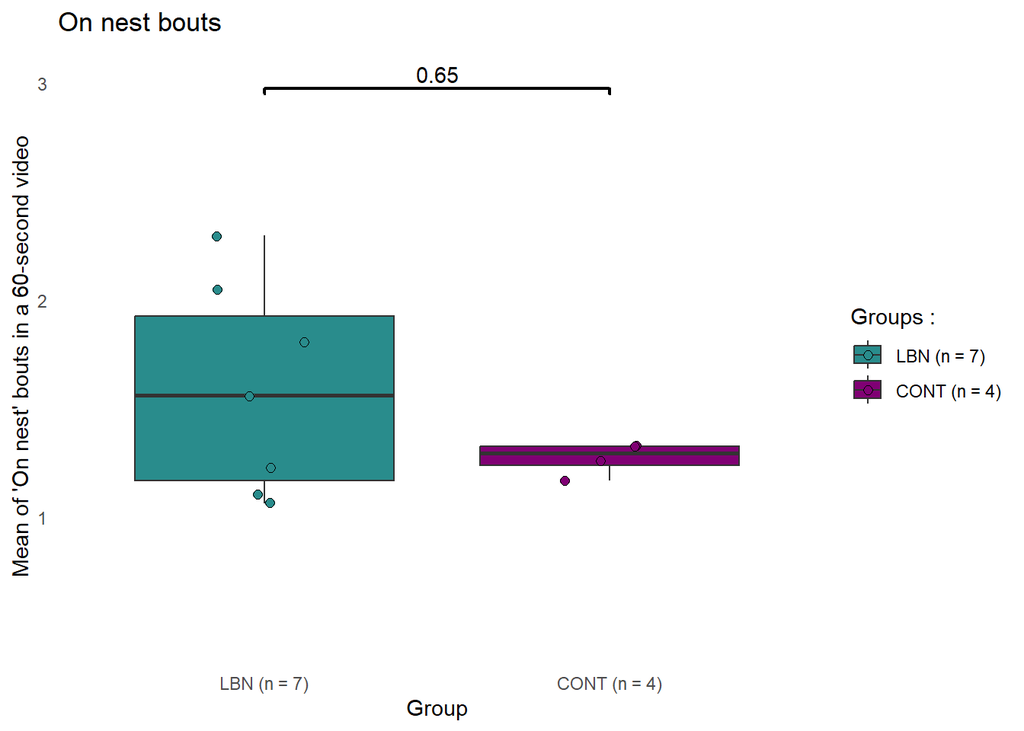

```r
summary_cage <- maternal_df %>%
  group_by(`Cage.ID`, Group) %>%
  summarise(
    Onnest_duration_mean = mean(Onnest_bouts, na.rm = TRUE),
    .groups = "drop"
  )

plot_behavior_boxplot(
  df = summary_cage,
  title = "On nest bouts",
  y_label = "Mean of 'On nest' bouts in a 60-second video",
  base_colors = c("LBN" = "#298c8c", "CONT" = "#800074"),
  value_column = "Onnest_duration_mean"
)
```

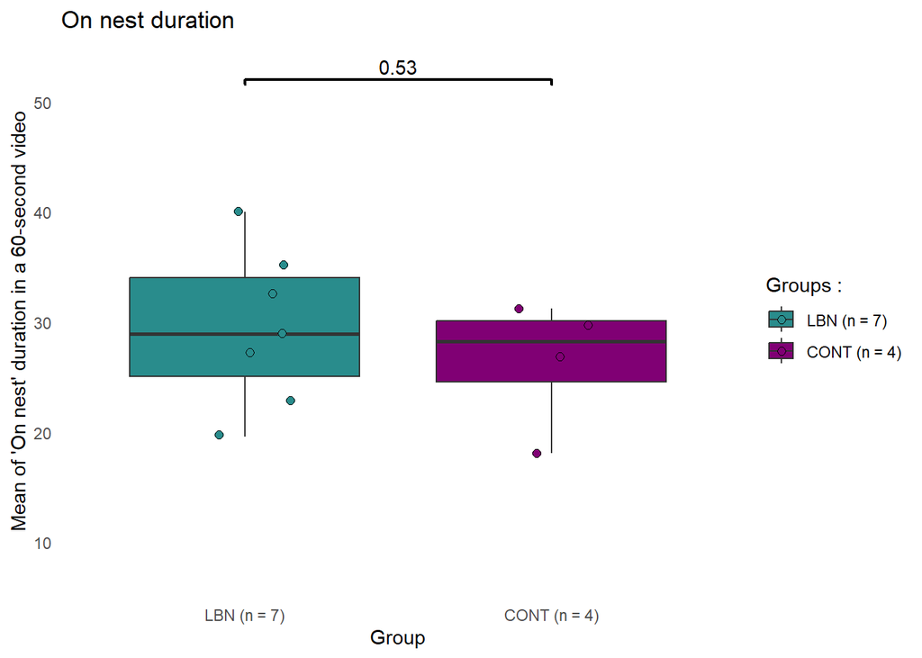

```r
summary_cage <- maternal_df %>%
  group_by(`Cage.ID`, Group) %>%
  summarise(
    Onnest_duration_mean = mean(Onnest_duration, na.rm = TRUE),
    .groups = "drop"
  )

plot_behavior_boxplot(
  df = summary_cage,
  title = "On nest duration",
  y_label = "Mean of 'On nest' duration in a 60-second video",
  base_colors = c("LBN" = "#298c8c", "CONT" = "#800074"),
  value_column = "Onnest_duration_mean"
)
```

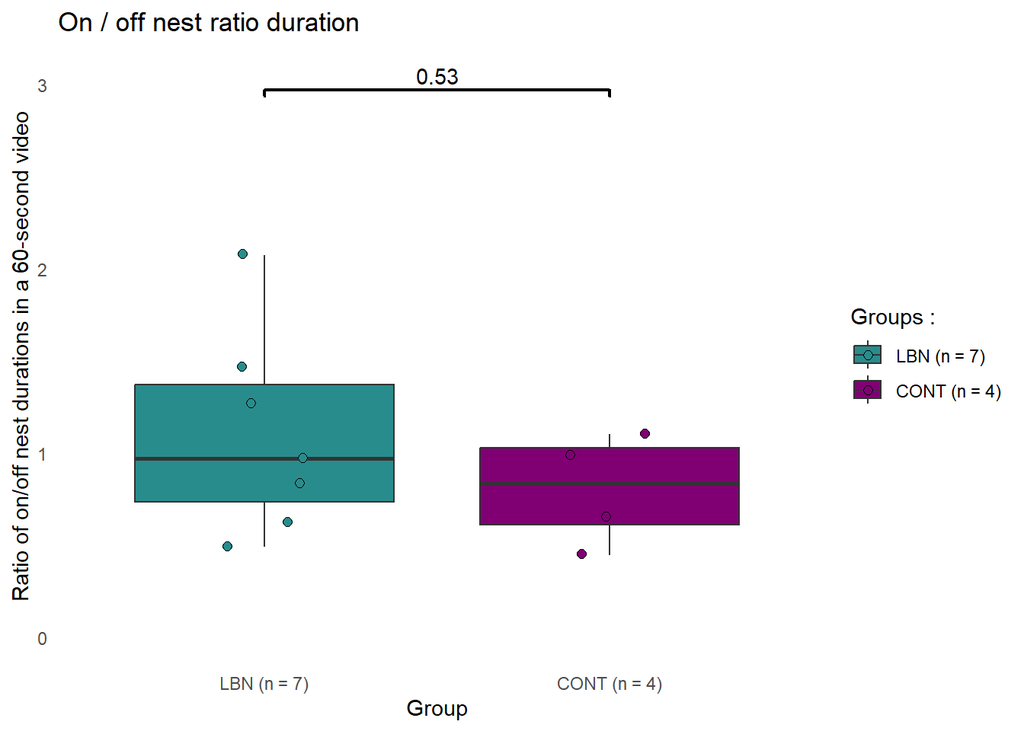

```r
summary_cage <- maternal_df %>%
  group_by(`Cage.ID`, Group) %>%
  summarise(
    Onnest_duration_mean = mean(Onnest_duration, na.rm = TRUE),
    Offnest_duration_mean = mean(Offnest_duration, na.rm = TRUE),
    .groups = "drop"
  ) %>%
  # Calcul des différences (Onnest - Offnest)
  mutate(
    duration_mean_diff = Onnest_duration_mean / Offnest_duration_mean
  )

plot_behavior_boxplot(
  df = summary_cage,
  title = "On / off nest ratio duration",
  y_label = "Ratio of on/off nest durations in a 60-second video",
  base_colors = c("LBN" = "#298c8c", "CONT" = "#800074"),
  value_column = "duration_mean_diff"
)
```

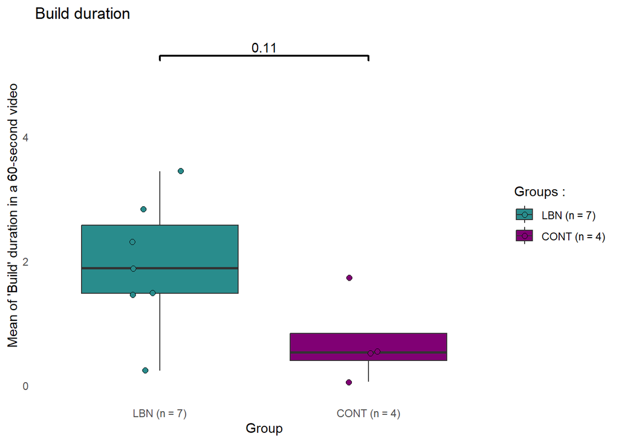

```r
summary_cage <- maternal_df %>%
  group_by(`Cage.ID`, Group) %>%
  summarise(
    Build_duration_mean = mean(Build_duration, na.rm = TRUE),
    .groups = "drop"
  )

plot_behavior_boxplot(
  df = summary_cage,
  title = "Build duration",
  y_label = "Mean of 'Build' duration in a 60-second video",
  base_colors = c("LBN" = "#298c8c", "CONT" = "#800074"),
  value_column = "Build_duration_mean"
)
```

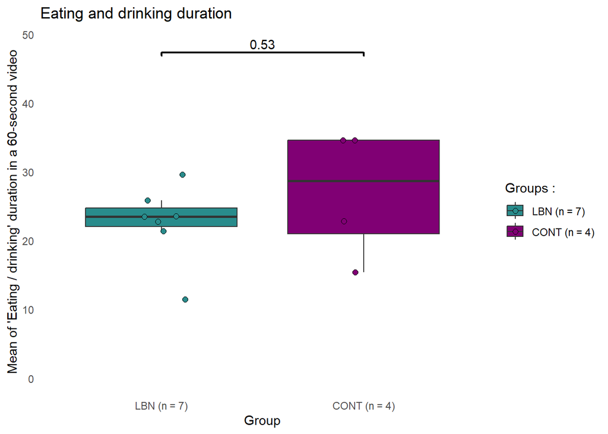

```r
summary_cage <- maternal_df %>%
  group_by(`Cage.ID`, Group) %>%
  summarise(
    Eat_drink_duration_mean = mean(Eat_drink_duration, na.rm = TRUE),
    .groups = "drop"
  )

plot_behavior_boxplot(
  df = summary_cage,
  title = "Eating and drinking duration",
  y_label = "Mean of 'Eating / drinking' duration in a 60-second video",
  base_colors = c("LBN" = "#298c8c", "CONT" = "#800074"),
  value_column = "Eat_drink_duration_mean"
)
```

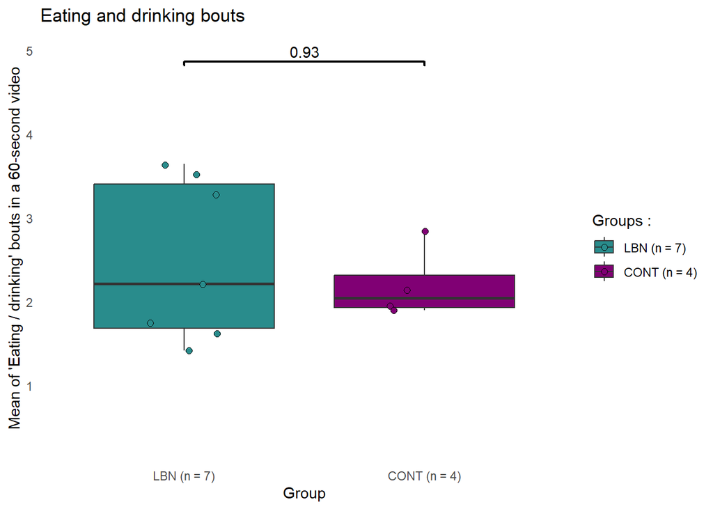

```r
summary_cage <- maternal_df %>%
  group_by(`Cage.ID`, Group) %>%
  summarise(
    Eat_drink_duration_mean = mean(Eat_drink_bouts, na.rm = TRUE),
    .groups = "drop"
  )

plot_behavior_boxplot(
  df = summary_cage,
  title = "Eating and drinking bouts",
  y_label = "Mean of 'Eating / drinking' bouts in a 60-second video",
  base_colors = c("LBN" = "#298c8c", "CONT" = "#800074"),
  value_column = "Eat_drink_duration_mean"
)
```

## Daily evolution

### On nest / off nest ratio evolution

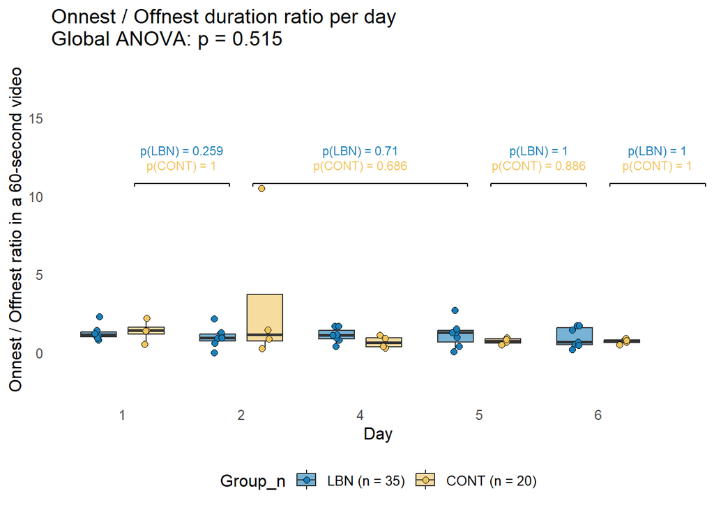

```r
summary_cage_diff <- maternal_df %>%
  group_by(`Cage.ID`, Group, Day) %>%
  summarise(
    Onnest_duration_mean = mean(Onnest_duration, na.rm = TRUE),
    Offnest_duration_mean = mean(Offnest_duration, na.rm = TRUE),
    .groups = "drop"
  ) %>%
  mutate(
    duration_mean_diff = ifelse(Offnest_duration_mean == 0, 0, Onnest_duration_mean / Offnest_duration_mean)
  )

plot_duration_ratio_with_wilcox(summary_cage_diff, "duration_mean_diff", "Onnest / Offnest duration ratio per day", "Onnest / Offnest ratio in a 60-second video", colors = c("LBN" = "#1a80bb", "CONT" = "#f2c45f"))
```

### Building per day evolution

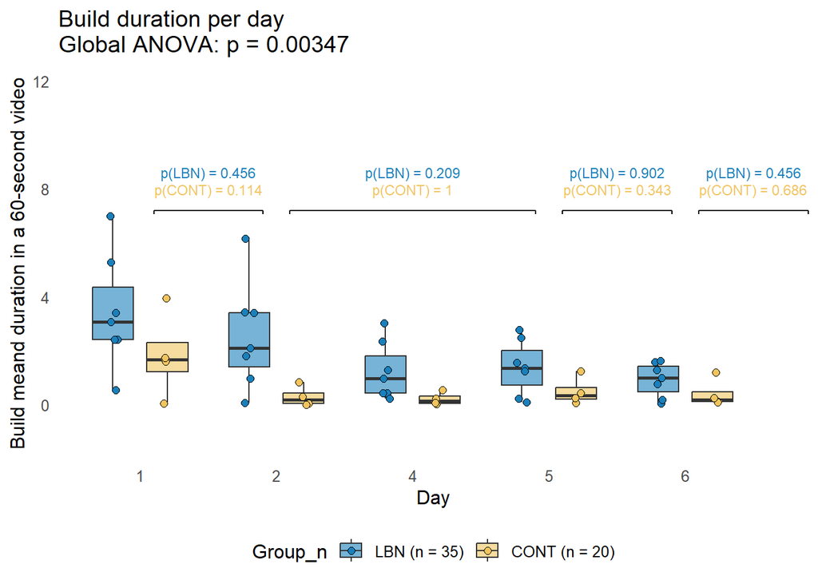

```r
build_summary <- maternal_df %>%
group_by(Cage.ID, Group, Day) %>%
summarise(Build_sum = mean(Build_duration, na.rm = TRUE), .groups = "drop")

plot_duration_ratio_with_wilcox(build_summary, "Build_sum", "Build duration per day", "Build meand duration in a 60-second video", colors = c("LBN" = "#1a80bb", "CONT" = "#f2c45f"))
```

### Transitions per day evolution

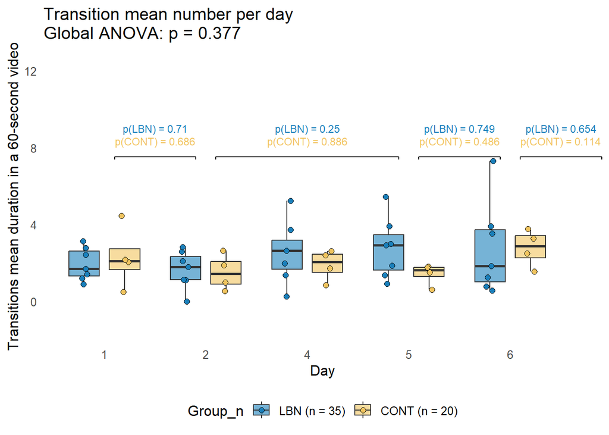

```r
transition_summary <- maternal_df %>%
group_by(Cage.ID, Group, Day) %>%
summarise(Transition = mean(Transition, na.rm = TRUE), .groups = "drop")

plot_duration_ratio_with_wilcox(transition_summary, "Transition", "Transition mean number per day", "Transitions mean duration in a 60-second video", colors = c("LBN" = "#1a80bb", "CONT" = "#f2c45f"))
```

### Changepoint and daily evolution

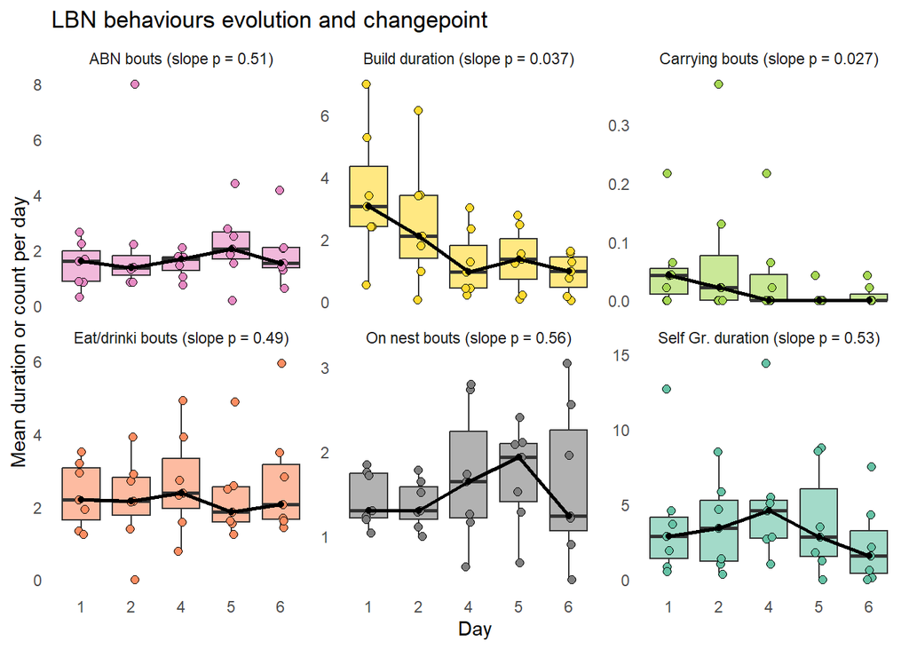

```r
# 1. Filtrer juste le groupe LBN
LBN_df <- maternal_df %>% filter(Group == "LBN")

# 2. Comportements d’intérêt
behaviors <- c("Selfgrooming_duration", "Eat_drink_bouts", "Onnest_bouts",
               "ABN_bouts", "Carryingpups_bouts", "Build_duration")

# 3. Mise en forme longue (long format)
LBN_long <- LBN_df %>%
  dplyr::select(Cage.ID, Day, dplyr::all_of(behaviors)) %>%
  pivot_longer(cols = dplyr::all_of(behaviors), names_to = "Behavior", values_to = "Bouts")


# 4. Renommer les comportements pour lisibilité
LBN_long$Behavior <- dplyr::recode(
  LBN_long$Behavior,
  "Selfgrooming_duration" = "Self Gr. duration",
  "Eat_drink_bouts" = "Eat/drinki bouts",
  "Onnest_bouts" = "On nest bouts",
  "ABN_bouts" = "ABN bouts",
  "Carryingpups_bouts" = "Carrying bouts",
  "Build_duration" = "Build duration"
)

# 8. Couleurs distinctes par comportement
color_palette <- c(
  "Self Gr. duration" = "#66c2a5",
  "Eat/drinki bouts" = "#fc8d62",
  "Transition bouts"   = "#8da0cb",
  "ABN bouts"           = "#e78ac3",
  "Carrying bouts" = "#a6d854",
  "Build duration"         = "#ffd92f"
)

# 5. Moyenne par cage, jour et comportement
LBN_cage_means <- LBN_long %>%
  group_by(Cage.ID, Day, Behavior) %>%
  summarise(mean_bouts = mean(Bouts, na.rm = TRUE), .groups = "drop")

# 6. Médianes par jour et comportement pour lignes
medians <- LBN_cage_means %>%
  group_by(Behavior, Day) %>%
  summarise(median_bouts = median(mean_bouts, na.rm = TRUE), .groups = "drop")

rupture_points <- medians %>%
  arrange(Behavior, Day) %>%
  group_by(Behavior) %>%
  summarise(
    change_day = {
      vec <- median_bouts
      cp <- cpt.mean(vec, method = "PELT", penalty = "MBIC")
      if (length(cpts(cp)) > 0) {
        Day[cpts(cp) + 0.5]
      } else {
        NA
      }
    },
    .groups = "drop"
  ) %>%
  filter(!is.na(change_day)) %>%
  mutate(change_day = as.numeric(change_day))


slopes <- medians %>%
  group_by(Behavior) %>%
  do({
    model <- lm(median_bouts ~ Day, data = .)
    p_val <- summary(model)$coefficients["Day", "Pr(>|t|)"]
    label <- paste0(unique(.$Behavior), " (slope p = ", signif(p_val, 2), ")")
    tibble(Behavior = unique(.$Behavior), label = label)
  })

# Joindre cette info à LBN_cage_means et medians
LBN_cage_means <- LBN_cage_means %>% left_join(slopes, by = "Behavior")
medians <- medians %>% left_join(slopes, by = "Behavior")
rupture_points <- rupture_points %>% left_join(slopes, by = "Behavior")

# 9. Graphique final
ggplot(LBN_cage_means, aes(x = factor(Day), y = mean_bouts, fill = Behavior)) +
  geom_boxplot(alpha = 0.6, outlier.shape = NA) +
  geom_jitter(
    shape = 21,
    size = 2,
    stroke = 0.3,
    color = "black",
    position = position_jitterdodge(jitter.width = 0.15, dodge.width = 0.8)
  ) +
  geom_line(data = medians, aes(x = factor(Day), y = median_bouts, group = 1),
            color = "black", size = 1, inherit.aes = FALSE) +
  geom_point(data = medians, aes(x = factor(Day), y = median_bouts),
             color = "black", size = 1.5, inherit.aes = FALSE) +
  geom_vline(data = rupture_points, aes(xintercept = change_day),
             color = "red", linetype = "dashed", size = 0.65) +
  facet_wrap(~ label, scales = "free_y") +
  scale_fill_manual(values = color_palette) +
  labs(
    title = "LBN behaviours evolution and changepoint",
    x = "Day",
    y = "Mean duration or count per day"
  ) +
  theme_minimal() +   theme(     panel.grid = element_blank()    ) +
  theme(legend.position = "none")
```

## Clustering

```r
maternal_means <- maternal_df %>%
  group_by(Cage.ID, Group) %>%
  summarise(across(where(is.numeric), mean, na.rm = TRUE), .groups = "drop")
meta_info <- maternal_df %>%
  group_by(Cage.ID) %>%
  summarise(
    PupID = first(PupID),
    Group = first(Group),
    .groups = "drop"
  )

# 3. Join pour enrichir avec PupID
maternal_means_full <- maternal_means %>%
  left_join(meta_info, by = "Cage.ID")

maternal_cleaned <- maternal_means_full %>%
  mutate(Group = coalesce(Group.x, Group.y)) %>%  # Choisir un seul "Group"
  group_by(Cage.ID, Group) %>%
  summarise(across(where(is.numeric), mean, na.rm = TRUE), .groups = "drop")

maternal_cleaned <- maternal_cleaned %>%
  dplyr::select(-c("Recording_duration", "Day", "Time"))

res_auto <- analyser_clusters_pca_mat(maternal_cleaned, colnames(maternal_cleaned),2, 3)
```

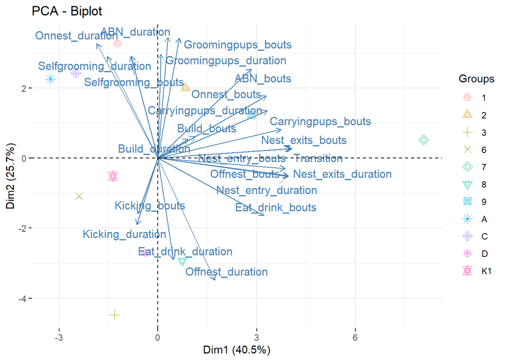

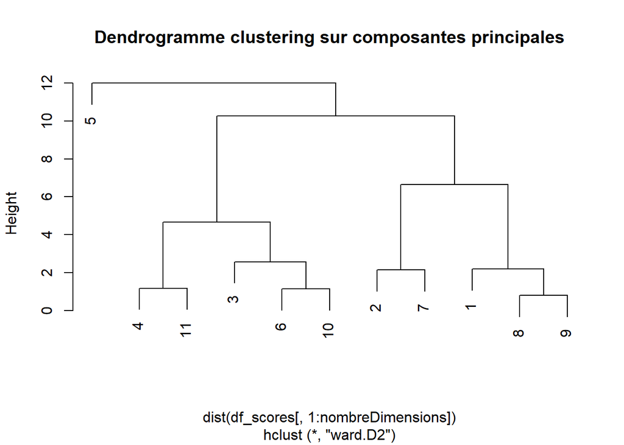

```
## Clustering avec k = 3
```

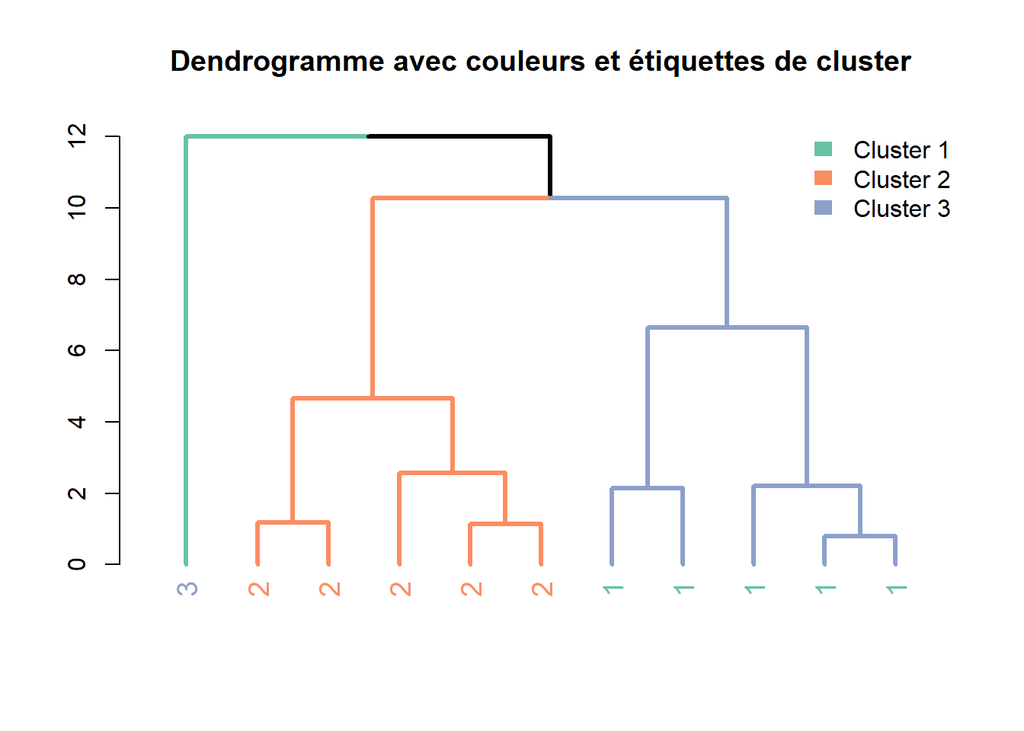

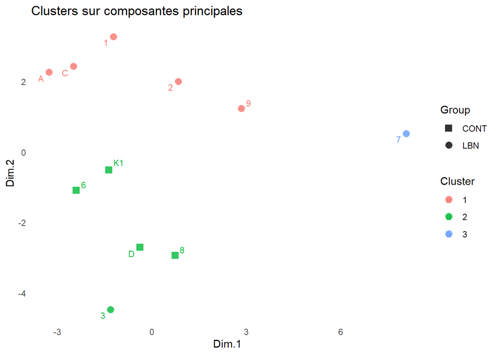

```
## # A tibble: 11 × 6
## # Groups:   Cage.ID [11]
##    Cage.ID cluster nb_obs total_obs prop_cluster Group
##    <fct>   <fct>    <int>     <int>        <dbl> <fct>
##  1 1       1            1         1            1 LBN
##  2 2       1            1         1            1 LBN
##  3 9       1            1         1            1 LBN
##  4 A       1            1         1            1 LBN
##  5 C       1            1         1            1 LBN
##  6 3       2            1         1            1 LBN
##  7 6       2            1         1            1 CONT
##  8 8       2            1         1            1 CONT
##  9 D       2            1         1            1 CONT
## 10 K1      2            1         1            1 CONT
## 11 7       3            1         1            1 LBN
```

## VAR

### Model creation

```r
fit_VAR_models <- function(df,
                           behav_vars = NULL,
                           frame_col = "frame",
                           bin_size = NULL,
                           lag = 1,
                           auto_lag = FALSE,
                           lag_max = 10,
                           verbose = TRUE) {

  df_proc <- df

  # Temporal binning si se especifica
  if (!is.null(bin_size)) {
    df_proc <- df_proc %>%
      mutate(time_bin = floor(.data[[frame_col]] / bin_size))
    time_unit <- "time_bin"
  } else {
    time_unit <- frame_col
  }

  # Definir ID de video = Cage + Start_time + Group
  df_proc <- df_proc %>%
    mutate(Video_ID = paste0(Cage, "_", Start_time, "_", Group, "_", Day))

  # Selección de variables de comportamiento si no se especifica
  if (is.null(behav_vars)) {
    vars_to_exclude <- c(frame_col, "time_bin", "Cage", "Start_time", "LBN",
                         "Recording_duration", "Sexe", "Group", "ID.blind",
                         "PupID", "background", "Cohort", "Project",
                         "Nest_exits", "Nest_entry", "Cage.ID", "Date", "Day",
                         "Time", "cluster", "Condition", "Video_ID")
    behav_vars <- setdiff(colnames(df_proc), vars_to_exclude)
  }

  if (verbose) print(glue::glue("Variables de comportamiento utilizadas: {toString(behav_vars)}"))

  # Eliminar NA en variables de comportamiento
  df_proc <- df_proc %>%
    drop_na(all_of(behav_vars))

  # Consolidar duplicados por Video_ID + time_unit
  df_unique <- df_proc %>%
    group_by(Video_ID, .data[[time_unit]]) %>%
    summarise(across(all_of(behav_vars), max, na.rm = TRUE), .groups = "drop") %>%
    arrange(Video_ID, .data[[time_unit]])

  # Separar por Video_ID
  data_groups <- df_unique %>%
    group_split(Video_ID)

  names(data_groups) <- df_unique %>%
    pull(Video_ID) %>%
    unique() %>%
    as.character()

  # Fit VAR por video
  var_models <- imap(data_groups, function(df_g, name) {
    ts_data <- ts(df_g %>% dplyr::select(all_of(behav_vars)), start = 0, frequency = 1)

    p <- lag
    if (auto_lag) {
      p <- tryCatch({
        VARselect(ts_data, lag.max = lag_max, type = "const")$selection["AIC(n)"]
      }, error = function(e) {
        warning(glue::glue("Lag auto fallido para {name}, usando p=1"))
        1
      })
    }


    tryCatch({
      VAR(ts_data, p = p, type = "const")
    }, error = function(e) {
      warning(glue::glue("Error VAR para {name}: {e$message}"))
      NULL
    })
  })

  return(var_models)
}
```

### Extract P matrix

```r
extract_P_matrix <- function(var_model) {
  coefs_list <- coef(var_model)
  variables <- names(coefs_list)  # Comportamientos como filas
  predictors <- rownames(coefs_list[[1]])
  predictors <- predictors[grepl(".l", predictors)]  # solo predictores con lags

  # Tus 9 comportamientos de interés
  beh_cols <- c("Onnest", "Offnest", "ABN", "Carryingpups",
                "Selfgrooming", "Eat_drink", "Kicking",
                "Groomingpups", "Build")

  n_vars <- length(variables)
  n_beh <- length(beh_cols)

  # Matriz P: filas = comportamientos observados, columnas = 9 comportamientos de interés
  P_matrix <- matrix(0, nrow = n_vars, ncol = n_beh)

  rownames(P_matrix) <- variables
  colnames(P_matrix) <- beh_cols

  for (i in seq_along(variables)) {
    for (j in seq_along(predictors)) {
      pred_name <- gsub(".l1", "", predictors[j])
      if (pred_name %in% beh_cols) {  # Solo si el predictor está en tus 9
        coef_value <- coefs_list[[i]][predictors[j], "Estimate"]
        P_matrix[variables[i], pred_name] <- coef_value
      }
    }
  }

  return(P_matrix)
}
```

### Visualization

```r
plot_VAR_graph <- function(coef_matrix,
                           var_name_labels = NULL,
                           min_width = 1,
                           max_width = 1.5,
                           edge_col = "#01cb01",
                           title = "Réseau comportemental VAR (probabilités de transition)") {
  # Matriz de coeficientes promedio
  coef_prom <- coef_matrix

  # Imprimir matriz cruda
  print(coef_prom)

  # Eliminar influencias negativas
  coef_prom[coef_prom < 0] <- 0

  # Calcular probabilidades de transición
  coef_prob <- coef_prom / rowSums(coef_prom)
  coef_prob[is.na(coef_prob)] <- 0

  # Normalizar anchos de aristas
  edge_width_norm <- (coef_prob - min(coef_prob)) / (max(coef_prob) - min(coef_prob))
  edge_width_norm <- edge_width_norm * (max_width - min_width) + min_width

  print(coef_prob)

  # Etiquetas de nodos
  if (is.null(var_name_labels)) {
    var_name_labels <- colnames(coef_prob)
  } else {
    colnames(coef_prob) <- var_name_labels
    rownames(coef_prob) <- var_name_labels
  }

  # Calcular tamaño de nodo
  max_label_length <- max(nchar(var_name_labels))
  node_size <- min(9, max_label_length * 1 )

  # Llamada a qgraph
  qgraph::qgraph(coef_prob,
    layout = "circle",
    directed = TRUE,
    edge.color = rep(edge_col, sum(coef_prob != 0, na.rm = TRUE)),
    edge.width = edge_width_norm[coef_prob != 0],
    labels = var_name_labels,
    label.cex = 1,
    label.font = 1.7,   # negrita
    vsize = node_size,
    border.width = 2,
    border.color = "black",
    legend = FALSE,
    title = title
  )
}
```

### Comparison

```r
compare_VAR_models <- function(model_A, model_B, exclude = NULL, plot = TRUE, title = "Differences") {

  # Función interna para extraer matriz de coeficientes
  extract_estimate_matrix <- function(var_model) {
    coef_list <- coef(var_model)
    var_names <- names(coef_list)
    pred_names <- rownames(coef_list[[1]])

    mat <- matrix(NA, nrow = length(pred_names), ncol = length(var_names),
                  dimnames = list(pred_names, var_names))

    for (var in var_names) {
      mat[, var] <- coef_list[[var]][, "Estimate"]
    }
    return(mat)
  }

  # Extraer las matrices
  A_mat <- extract_estimate_matrix(model_A)
  B_mat <- extract_estimate_matrix(model_B)

  # Asegurar coincidencia de filas/columnas
  common_rows <- intersect(rownames(A_mat), rownames(B_mat))
  common_cols <- intersect(colnames(A_mat), colnames(B_mat))

  A_common <- A_mat[common_rows, common_cols, drop = FALSE]
  B_common <- B_mat[common_rows, common_cols, drop = FALSE]

  # Matriz de diferencias
  diff_mat <- A_common - B_common

  # Excluir comportamientos si se pide
  if (!is.null(exclude)) {
    exclude_lags <- paste0(exclude, ".l1")
    diff_mat <- diff_mat[
      !(rownames(diff_mat) %in% exclude_lags) & rownames(diff_mat) != "const",
      !(colnames(diff_mat) %in% exclude),
      drop = FALSE
    ]
  }

  # Filtrar para qgraph: variables presentes en filas y columnas
  row_vars <- gsub(".l1", "", rownames(diff_mat))
  col_vars <- colnames(diff_mat)
  valid_vars <- intersect(row_vars, col_vars)

  diff_filtered <- diff_mat[paste0(valid_vars, ".l1"), valid_vars, drop = FALSE]

  print(diff_filtered)
  # Graficar si se desea
  if (plot) {
    qgraph::qgraph(diff_filtered,
           layout = "circle",
           directed = TRUE,
           edge.labels = TRUE,
           title = title)
  }

  return(diff_filtered)
}
```

# Pup’s analysis

## All variables testing

### Body weight change

```r
compute_BW_stats <- function(df) {
  df_long <- df %>%
    pivot_longer(
      cols = starts_with("BW.P"),
      names_to = "Jour",
      values_to = "Valeur"
    ) %>%
    filter(!is.na(Valeur)) %>%
    mutate(Jour_num = as.numeric(sub("BW.P", "", Jour)))

  df_stats <- df_long %>%
    group_by(PupID) %>%
    summarise(
      BW.auc = sum(diff(Jour_num) * (head(Valeur, -1) + tail(Valeur, -1)) / 2),
      lm_fit = list(lm(Valeur ~ Jour_num)),
      .groups = "drop"
    ) %>%
    mutate(
      slope = map_dbl(lm_fit, ~ coef(.x)[["Jour_num"]]),
      rsq = map_dbl(lm_fit, ~ summary(.x)$r.squared)
    ) %>%
    dplyr::select(-lm_fit)

  df %>% left_join(df_stats, by = "PupID")
}

juvenile_df <- compute_BW_stats(juvenile_df)
juvenile_all_completed <- compute_BW_stats(juvenile_all_completed)
juvenile_df_only <- compute_BW_stats(juvenile_df_only)
juvenile_unic_completed <- compute_BW_stats(juvenile_unic_completed)
```

### Variable filtering

```r
# Liste initiale des colonnes à supprimer
cols_to_eliminate <- c(
  "av.geotax.lat", "av.front.lat", "av.grasp.lat",
  "exit.tube", "BW.auc", "rsq"
)

# Ajouter dynamiquement les colonnes qui commencent par BW.P et flip.lat.p
cols_to_eliminate <- c(
  cols_to_eliminate,
  names(juvenile_df)[startsWith(names(juvenile_df), "BW.P")],
  names(juvenile_df)[startsWith(names(juvenile_df), "flip.lat.p")]
)

# Garder uniquement les colonnes qui existent vraiment dans le dataframe
cols_to_eliminate <- cols_to_eliminate[cols_to_eliminate %in% names(juvenile_df)]

# Supprimer les colonnes
juvenile_df <- juvenile_df %>% dplyr::select(-all_of(cols_to_eliminate))

# Répéter pour juvenile_all_completed
cols_to_eliminate <- c(
  "av.geotax.lat", "av.front.lat", "av.grasp.lat",
  "exit.tube", "BW.auc", "rsq",
  names(juvenile_all_completed)[startsWith(names(juvenile_all_completed), "BW.P")],
  names(juvenile_all_completed)[startsWith(names(juvenile_all_completed), "flip.lat.p")]
)

cols_to_eliminate <- cols_to_eliminate[cols_to_eliminate %in% names(juvenile_all_completed)]

juvenile_all_completed <- juvenile_all_completed %>% dplyr::select(-all_of(cols_to_eliminate))

# Répéter pour juvenile_all_completed
cols_to_eliminate <- c(
  "av.geotax.lat", "av.front.lat", "av.grasp.lat",
  "exit.tube", "BW.auc", "rsq",
  names(juvenile_unic_completed)[startsWith(names(juvenile_unic_completed), "BW.P")],
  names(juvenile_unic_completed)[startsWith(names(juvenile_unic_completed), "flip.lat.p")]
)

cols_to_eliminate <- cols_to_eliminate[cols_to_eliminate %in% names(juvenile_unic_completed)]

juvenile_unic_completed <- juvenile_unic_completed %>% dplyr::select(-all_of(cols_to_eliminate))



physical_variables <- c("d.ear.twicth", "d.ear.c.open", "d.eye.l.open", "BW.auc")

motor_variables <- c("flip.AUC.p7.10", "norm.av.grasp.lat", "norm.av.front.lat", "d.transition", "d.walk")

transcriptomal_variables <- c("Cortp",  "CDK9", "DGKH", "FKBP5",    "HSP90AA1", "HSP90AB1", "NFATC1",   "NR3C1",    "PTGES3",   "SGK1", "SGK3", "SKA2", "STAT5A")

dam_missing_variables <- c("av.freq.p3",    "av.ep.dur.p3", "lat.p3",   "tot.n.voc.p14",    "av.freq.p14",  "av.ep.dur.p14",    "lat.p14")
```

### Variable testing

```r
# 1. Vérifier quelles colonnes sont numériques
num_cols <- sapply(juvenile_df, is.numeric)

# 2. Fonction Shapiro sur les colonnes (brutes)
shapiro_fun <- function(x) {
  x <- na.omit(x)
  if (length(x) < 3 || length(x) > 5000) return(NA)
  shapiro.test(x)$p.value
}

# 3. Calcul normalité des colonnes numériques
normality_df <- data.frame(
  Variable = names(juvenile_df)[num_cols],
  N        = sapply(juvenile_df[ , num_cols, drop = FALSE], function(x) sum(!is.na(x))),
  P_value  = sapply(juvenile_df[ , num_cols, drop = FALSE], shapiro_fun)
)

normality_df$Normalité_OK <- with(normality_df, P_value > 0.05 | N > 60)

print(normality_df)
```

```
##                    Variable  N      P_value Normalité_OK
## d.ear.twicth   d.ear.twicth 69 2.367740e-11         TRUE
## d.ear.c.open   d.ear.c.open 69 6.394847e-13         TRUE
## d.eye.l.open   d.eye.l.open 58 4.882854e-06        FALSE
## d.transition   d.transition 65 1.512478e-06         TRUE
## d.walk               d.walk 58 1.811520e-06        FALSE
## tot.n.voc.p14 tot.n.voc.p14 78 8.701671e-13         TRUE
## slope                 slope 78 3.250038e-12         TRUE
```

```r
# 4. Liste des variables numériques
num_vars <- names(juvenile_df)[sapply(juvenile_df, is.numeric)]

# 5. Fonction principale d’analyse
analyze_var <- function(var_name) {
  results <- list()
  df_tibble <- as_tibble(juvenile_df)

  # Essayer modèles paramétriques (ANOVA) et fallback si nécessaire
  for (i in 1:3) {
    form <- switch(i,
                   as.formula(paste(var_name, "~ Condition")),
                   as.formula(paste(var_name, "~ CageID")),
                   as.formula(paste(var_name, "~ Condition * CageID")),
                   NULL)

    if (!is.null(form)) {
      model <- tryCatch(lm(form, data = df_tibble), error = function(e) NULL)
      if (!is.null(model)) {
        shapiro_p <- tryCatch(shapiro.test(residuals(model))$p.value, error = function(e) NA)
        aov_result <- tryCatch(anova(model), error = function(e) NULL)

        if (!is.null(aov_result)) {
          p_values <- aov_result$`Pr(>F)`
          factors <- rownames(aov_result)
          padj <- p.adjust(p_values, method = "bonferroni")

          # Si les résidus ne sont pas normaux → Kruskal
          if (!is.na(shapiro_p) && shapiro_p <= 0.05) {
            if (i == 1) {
              data_sub <- df_tibble %>%
                dplyr::select(all_of(c(var_name, "Condition"))) %>%
                filter(!is.na(.data[[var_name]]))
              kw_test <- tryCatch(kruskal.test(data_sub[[var_name]] ~ data_sub$Condition), error = function(e) NULL)
              if (!is.null(kw_test)) {
                df_model <- data.frame(
                  Variable  = var_name,
                  Modele    = "Modèle_1",
                  Facteur   = "Condition",
                  P_value   = kw_test$p.value,
                  P_adj     = NA,
                  Test      = "Kruskal-Wallis",
                  Shapiro_p = shapiro_p
                )
                results[[length(results) + 1]] <- df_model
              }
            } else if (i == 2) {
              data_sub <- df_tibble %>%
                dplyr::select(all_of(c(var_name, "CageID"))) %>%
                filter(!is.na(.data[[var_name]]), !is.na(CageID))
              kw_test <- tryCatch(kruskal.test(data_sub[[var_name]] ~ data_sub$CageID), error = function(e) NULL)
              if (!is.null(kw_test)) {
                df_model <- data.frame(
                  Variable  = var_name,
                  Modele    = "Modèle_2",
                  Facteur   = "CageID",
                  P_value   = kw_test$p.value,
                  P_adj     = NA,
                  Test      = "Kruskal-Wallis",
                  Shapiro_p = shapiro_p
                )
                results[[length(results) + 1]] <- df_model
              }
            }
          } else {
            # Résidus OK → garder ANOVA
            df_model <- data.frame(
              Variable  = var_name,
              Modele    = paste0("Modèle_", i),
              Facteur   = factors,
              P_value   = p_values,
              P_adj     = padj,
              Test      = "ANOVA",
              Shapiro_p = shapiro_p
            )
            results[[length(results) + 1]] <- df_model
          }
        }
      }
    }
  }

  # Modèle 3 et 5 : Kruskal-Wallis CageID selon Condition (LBN/CONT)
  for (cond in c("LBN", "CONT")) {
    data_sub <- df_tibble %>%
      dplyr::select(all_of(c(var_name, "Condition", "CageID"))) %>%
      filter(!is.na(.data[[var_name]]), Condition == cond, !is.na(CageID))

    if (nrow(data_sub) > 2) {
      kw_test <- tryCatch(kruskal.test(data_sub[[var_name]] ~ data_sub$CageID), error = function(e) NULL)
      if (!is.null(kw_test)) {
        df_model <- data.frame(
          Variable  = var_name,
          Modele    = paste0("Modèle_", ifelse(cond == "LBN", "3", "5")),
          Facteur   = paste0("CageID (", cond, ")"),
          P_value   = kw_test$p.value,
          P_adj     = NA,
          Test      = "Kruskal-Wallis",
          Shapiro_p = NA
        )
        results[[length(results) + 1]] <- df_model
      }
    }
  }

  results <- bind_rows(results)

  # Correction intra-modèle
  results <- results %>%
    group_by(Modele) %>%
    mutate(P_adj_model = p.adjust(P_value, method = "bonferroni")) %>%
    ungroup()

  # Correction globale
  results$P_adj_global <- p.adjust(results$P_value, method = "bonferroni")

  return(results)
}

# 6. Lancer l'analyse pour chaque variable numérique
juvenile_df <- as_tibble(juvenile_df)
results_list <- lapply(num_vars, analyze_var)
full_results <- bind_rows(results_list)

# 7. Correction finale globale (si besoin)
full_results$P_adj <- p.adjust(full_results$P_value, method = "bonferroni")
```

### Important variables

```r
# Cage effects - normal (based on P_adj_global)
cage_impacted_normal <- full_results %>%
  filter(
    str_detect(Facteur, "CageID") | str_detect(Facteur, "CageID \\(CONT\\)") | str_detect(Facteur, "CageID \\(LBN\\)"),
    P_adj_global < 0.05 | (is.na(P_adj) & P_value < 0.05)
  ) %>%
  pull(Variable) %>%
  unique()


# Cage effects - strict (based on P_adj)
cage_impacted_strict <- full_results %>%
  filter(
    str_detect(Facteur, "CageID") | str_detect(Facteur, "CageID \\(CONT\\)") | str_detect(Facteur, "CageID \\(LBN\\)"),
    P_adj < 0.05 | (is.na(P_adj) & P_value < 0.05)
  ) %>%
  pull(Variable) %>%
  unique()

# Condition effects - normal (with global adjusted p)
condition_impacted_normal <- full_results %>%
  filter(
    str_detect(Facteur, "Condition") &
    str_detect(Modele, "Modèle_1") &
    (P_adj_global < 0.05 | (is.na(P_adj) & P_value < 0.05))
  ) %>%
  pull(Variable) %>%
  unique()



# Condition effects - strict (with adjusted p)
condition_impacted_strict <- full_results %>%
  filter(
    str_detect(Facteur, "Condition") &
    str_detect(Modele, "Modèle_1") &
    (P_adj < 0.05 | (is.na(P_adj) & P_value < 0.05))
  ) %>%
  pull(Variable) %>%
  unique()
```

### LBN impacts

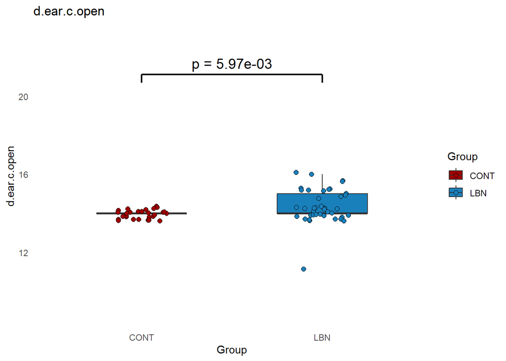

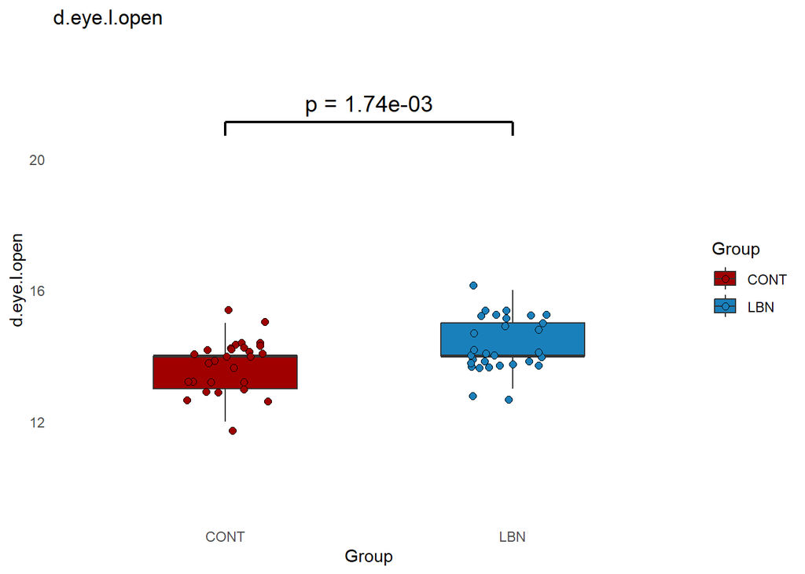

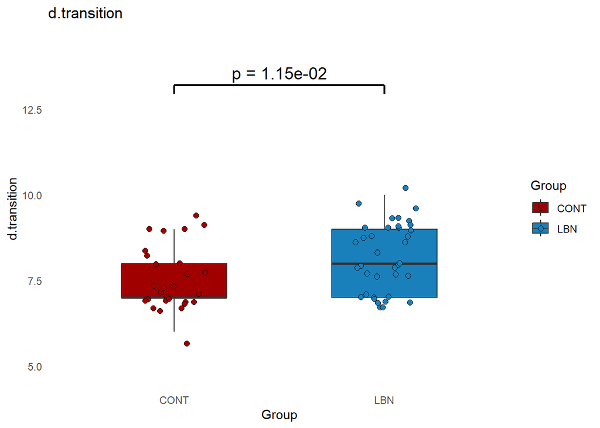

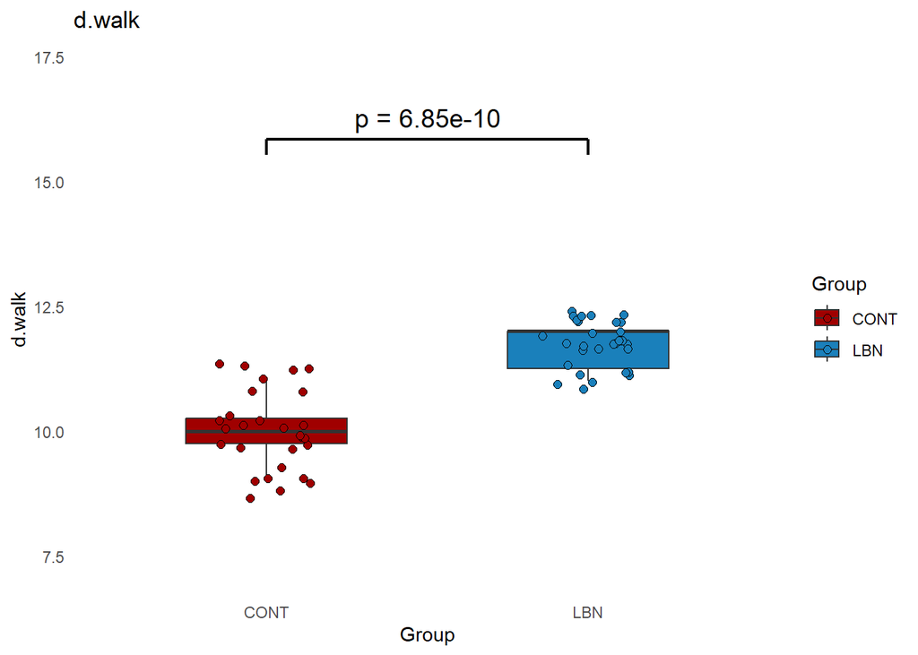

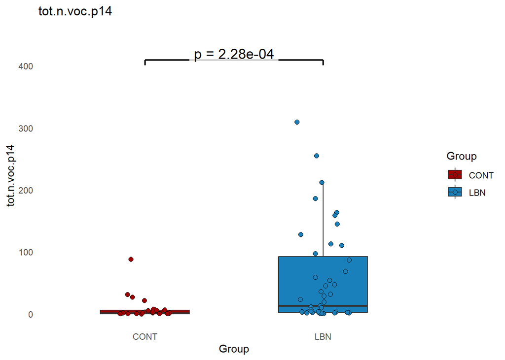

```r
fill_colors <- c("CONT" = "#a00000", "LBN" = "#1a80bb")

walk(condition_impacted_normal, ~{
  print(plot_variable_box(
    df = juvenile_df,
    df_condition = full_results,
    var_name = .x,
    fill_colors = fill_colors,
    y_label = paste(.x)
  ))
})
```

## PCA

### All very important variables - true data

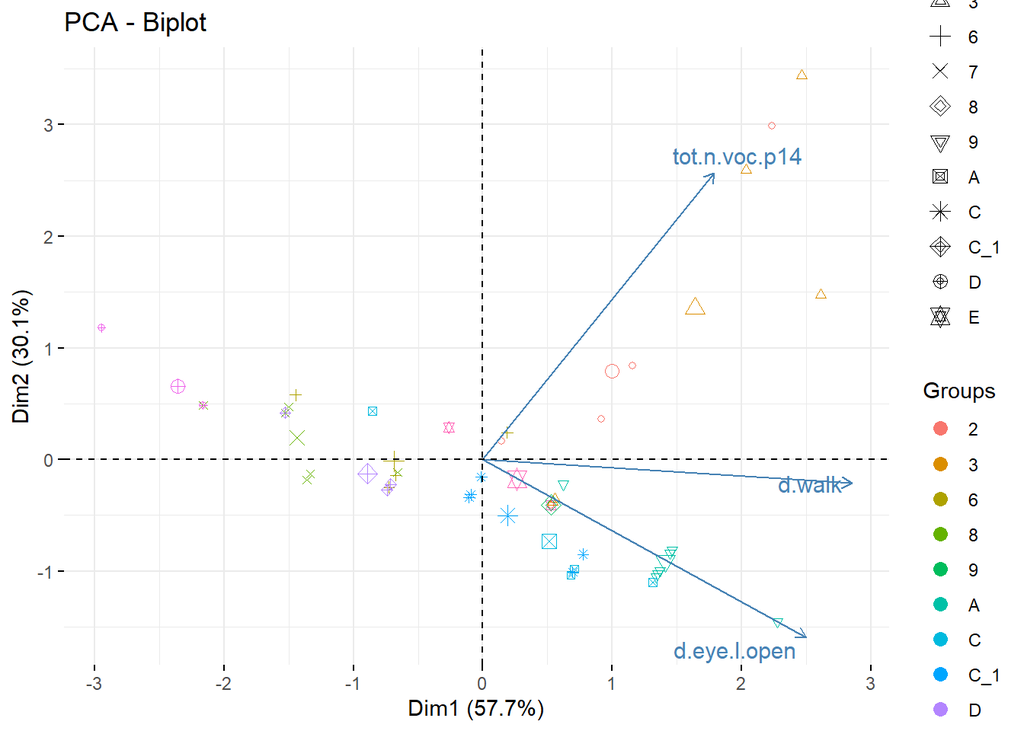

```
##
## Call:
## PCA(X = df_numeric, scale.unit = TRUE, graph = FALSE)
##
##
## Eigenvalues
##                        Dim.1   Dim.2   Dim.3
## Variance               1.731   0.903   0.367
## % of var.             57.685  30.093  12.223
## Cumulative % of var.  57.685  87.777 100.000
##
## Individuals (the 10 first)
##                   Dist    Dim.1    ctr   cos2    Dim.2    ctr   cos2    Dim.3
## 1             |  2.820 |  2.276  5.544  0.651 | -1.451  4.316  0.265 |  0.817
## 2             |  1.699 |  1.355  1.965  0.636 | -1.022  2.141  0.362 | -0.082
## 3             |  1.673 |  1.449  2.246  0.750 | -0.836  1.433  0.250 | -0.013
## 4             |  1.705 |  1.342  1.927  0.619 | -1.048  2.254  0.378 | -0.092
## 5             |  1.671 |  1.462  2.288  0.765 | -0.809  1.344  0.235 | -0.003
## 6             |  1.694 |  1.369  2.004  0.653 | -0.995  2.031  0.345 | -0.072
## 7             |  1.070 |  0.621  0.413  0.337 | -0.221  0.100  0.043 | -0.843
## 8             |  1.719 |  1.315  1.851  0.585 | -1.101  2.488  0.410 | -0.112
## 9             |  1.364 |  0.681  0.496  0.249 | -1.036  2.200  0.577 |  0.569
## 10            |  1.346 |  0.708  0.536  0.276 | -0.983  1.980  0.533 |  0.589
##                  ctr   cos2
## 1              3.375  0.084 |
## 2              0.034  0.002 |
## 3              0.001  0.000 |
## 4              0.043  0.003 |
## 5              0.000  0.000 |
## 6              0.026  0.002 |
## 7              3.590  0.620 |
## 8              0.063  0.004 |
## 9              1.634  0.174 |
## 10             1.750  0.191 |
##
## Variables
##                  Dim.1    ctr   cos2    Dim.2    ctr   cos2    Dim.3    ctr
## d.eye.l.open  |  0.785 35.564  0.615 | -0.500 27.659  0.250 |  0.367 36.777
## d.walk        |  0.895 46.241  0.800 | -0.067  0.497  0.004 | -0.442 53.263
## tot.n.voc.p14 |  0.561 18.196  0.315 |  0.805 71.844  0.649 |  0.191  9.960
##                 cos2
## d.eye.l.open   0.135 |
## d.walk         0.195 |
## tot.n.voc.p14  0.037 |
```

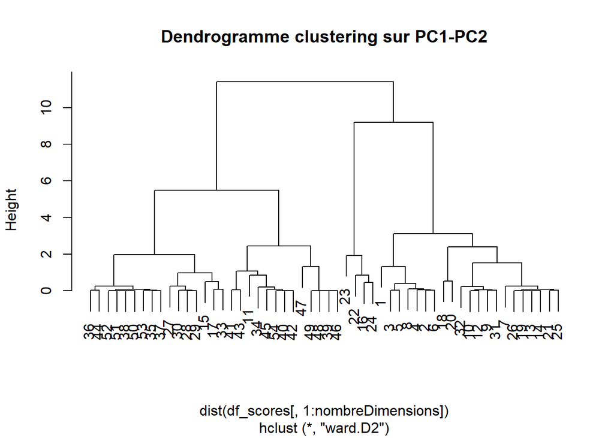

```
## Clustering automatique avec cutreeDynamic()
```

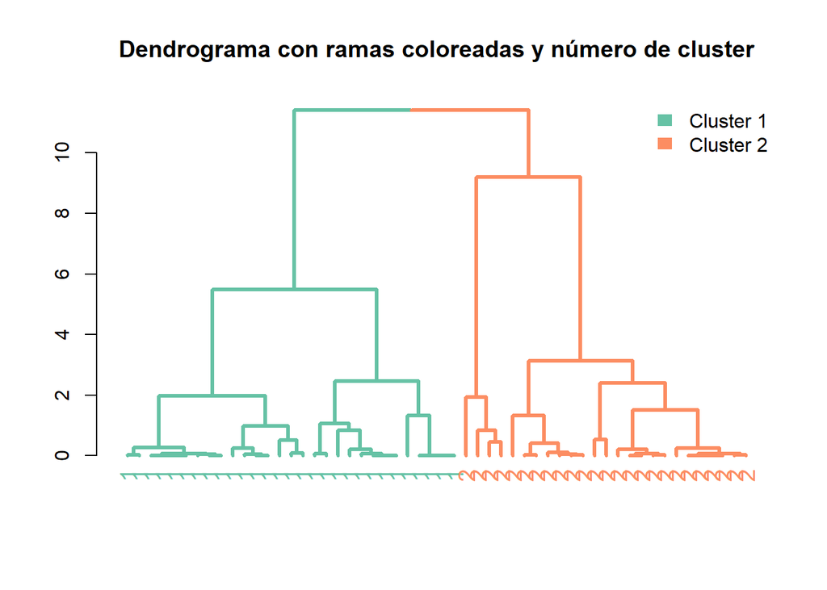

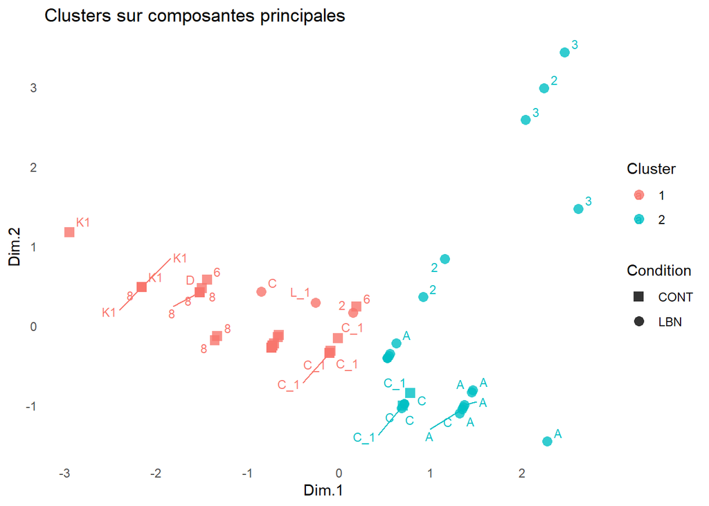

```
## # A tibble: 11 × 6
## # Groups:   CageID [11]
##    CageID cluster nb_obs total_obs prop_cluster Condition
##    <fct>  <fct>    <int>     <int>        <dbl> <fct>
##  1 6      1            6         6        1     CONT
##  2 8      1            7         7        1     CONT
##  3 D      1            5         5        1     CONT
##  4 K1     1            4         4        1     CONT
##  5 C_1    1            4         6        0.667 CONT
##  6 3      2            5         5        1     LBN
##  7 9      2            1         1        1     LBN
##  8 A      2            7         7        1     LBN
##  9 2      2            4         5        0.8   LBN
## 10 C      2            4         5        0.8   LBN
## 11 L_1    2            2         3        0.667 LBN
```

```
## $pca
## **Results for the Principal Component Analysis (PCA)**
## The analysis was performed on 54 individuals, described by 3 variables
## *The results are available in the following objects:
##
##    name               description
## 1  "$eig"             "eigenvalues"
## 2  "$var"             "results for the variables"
## 3  "$var$coord"       "coord. for the variables"
## 4  "$var$cor"         "correlations variables - dimensions"
## 5  "$var$cos2"        "cos2 for the variables"
## 6  "$var$contrib"     "contributions of the variables"
## 7  "$ind"             "results for the individuals"
## 8  "$ind$coord"       "coord. for the individuals"
## 9  "$ind$cos2"        "cos2 for the individuals"
```

[output cut: 80 more lines]

```r
analyser_clusters_pca(juvenile_df, condition_impacted_strict, 2, -1)
```

First results validated = Good separation between CONT and LBN - 8 observable groups

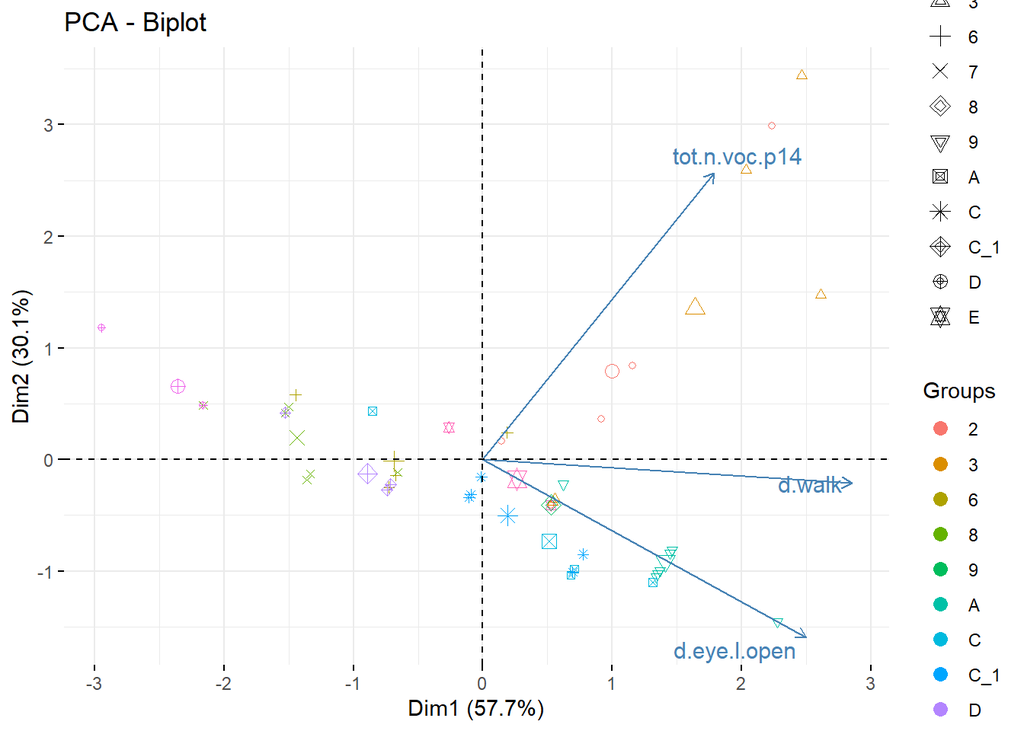

```
##
## Call:
## PCA(X = df_numeric, scale.unit = TRUE, graph = FALSE)
##
##
## Eigenvalues
##                        Dim.1   Dim.2   Dim.3
## Variance               1.731   0.903   0.367
## % of var.             57.685  30.093  12.223
## Cumulative % of var.  57.685  87.777 100.000
##
## Individuals (the 10 first)
##                   Dist    Dim.1    ctr   cos2    Dim.2    ctr   cos2    Dim.3
## 1             |  2.820 |  2.276  5.544  0.651 | -1.451  4.316  0.265 |  0.817
## 2             |  1.699 |  1.355  1.965  0.636 | -1.022  2.141  0.362 | -0.082
## 3             |  1.673 |  1.449  2.246  0.750 | -0.836  1.433  0.250 | -0.013
## 4             |  1.705 |  1.342  1.927  0.619 | -1.048  2.254  0.378 | -0.092
## 5             |  1.671 |  1.462  2.288  0.765 | -0.809  1.344  0.235 | -0.003
## 6             |  1.694 |  1.369  2.004  0.653 | -0.995  2.031  0.345 | -0.072
## 7             |  1.070 |  0.621  0.413  0.337 | -0.221  0.100  0.043 | -0.843
## 8             |  1.719 |  1.315  1.851  0.585 | -1.101  2.488  0.410 | -0.112
## 9             |  1.364 |  0.681  0.496  0.249 | -1.036  2.200  0.577 |  0.569
## 10            |  1.346 |  0.708  0.536  0.276 | -0.983  1.980  0.533 |  0.589
##                  ctr   cos2
## 1              3.375  0.084 |
## 2              0.034  0.002 |
## 3              0.001  0.000 |
## 4              0.043  0.003 |
## 5              0.000  0.000 |
## 6              0.026  0.002 |
## 7              3.590  0.620 |
## 8              0.063  0.004 |
## 9              1.634  0.174 |
## 10             1.750  0.191 |
##
## Variables
##                  Dim.1    ctr   cos2    Dim.2    ctr   cos2    Dim.3    ctr
## d.eye.l.open  |  0.785 35.564  0.615 | -0.500 27.659  0.250 |  0.367 36.777
## d.walk        |  0.895 46.241  0.800 | -0.067  0.497  0.004 | -0.442 53.263
## tot.n.voc.p14 |  0.561 18.196  0.315 |  0.805 71.844  0.649 |  0.191  9.960
##                 cos2
## d.eye.l.open   0.135 |
## d.walk         0.195 |
## tot.n.voc.p14  0.037 |
```

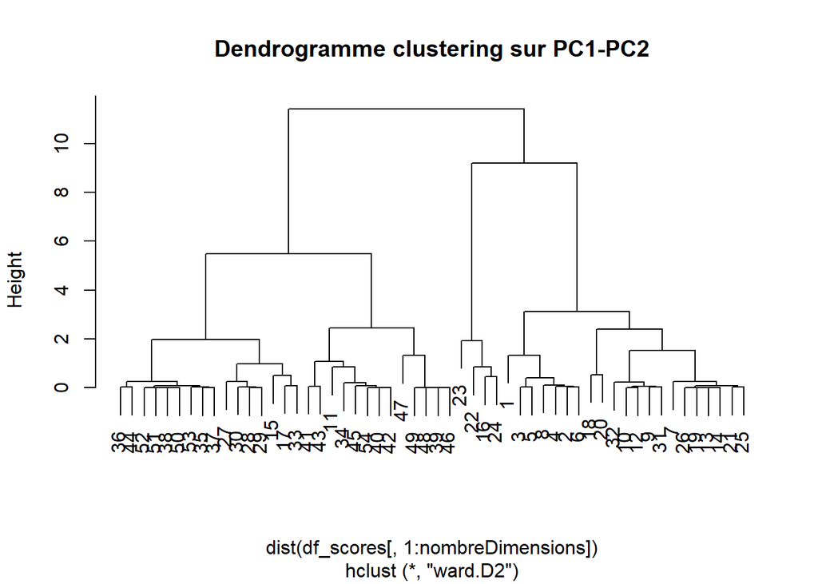

```
## Clustering avec k = 8
```

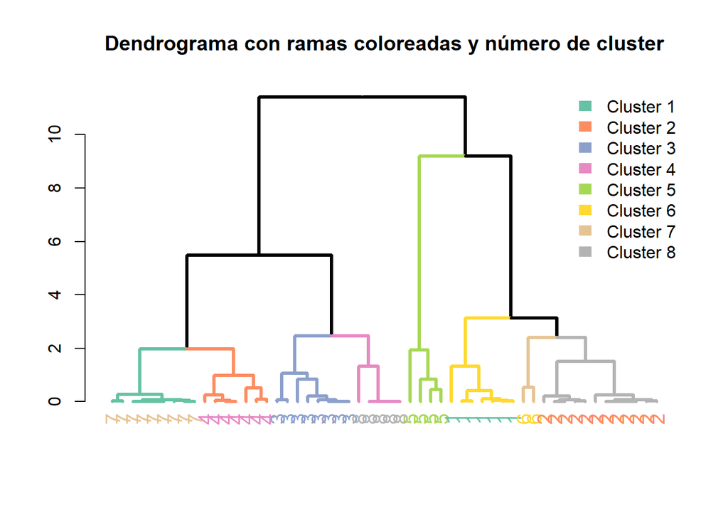

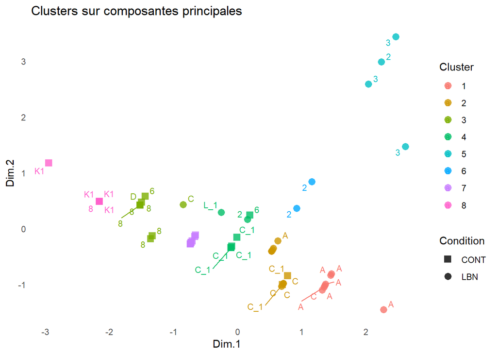

```
## # A tibble: 11 × 6
## # Groups:   CageID [11]
##    CageID cluster nb_obs total_obs prop_cluster Condition
##    <fct>  <fct>    <int>     <int>        <dbl> <fct>
##  1 A      1            6         7        0.857 LBN
##  2 9      2            1         1        1     LBN
##  3 L_1    2            2         3        0.667 LBN
##  4 C      2            3         5        0.6   LBN
##  5 8      3            5         7        0.714 CONT
##  6 C_1    4            4         6        0.667 CONT
##  7 3      5            3         5        0.6   LBN
##  8 2      6            2         5        0.4   LBN
##  9 D      7            4         5        0.8   CONT
## 10 6      7            4         6        0.667 CONT
## 11 K1     8            4         4        1     CONT
```

```
## $pca
## **Results for the Principal Component Analysis (PCA)**
## The analysis was performed on 54 individuals, described by 3 variables
## *The results are available in the following objects:
##
##    name               description
## 1  "$eig"             "eigenvalues"
## 2  "$var"             "results for the variables"
## 3  "$var$coord"       "coord. for the variables"
## 4  "$var$cor"         "correlations variables - dimensions"
## 5  "$var$cos2"        "cos2 for the variables"
## 6  "$var$contrib"     "contributions of the variables"
## 7  "$ind"             "results for the individuals"
## 8  "$ind$coord"       "coord. for the individuals"
## 9  "$ind$cos2"        "cos2 for the individuals"
```

[output cut: 80 more lines]

```r
analyser_clusters_pca(juvenile_df, condition_impacted_strict, 2, 8)
```

### All important variables - Corrected data

```r
clusters <- analyser_clusters_pca(juvenile_all_completed, condition_impacted_normal, 3, -1)
```

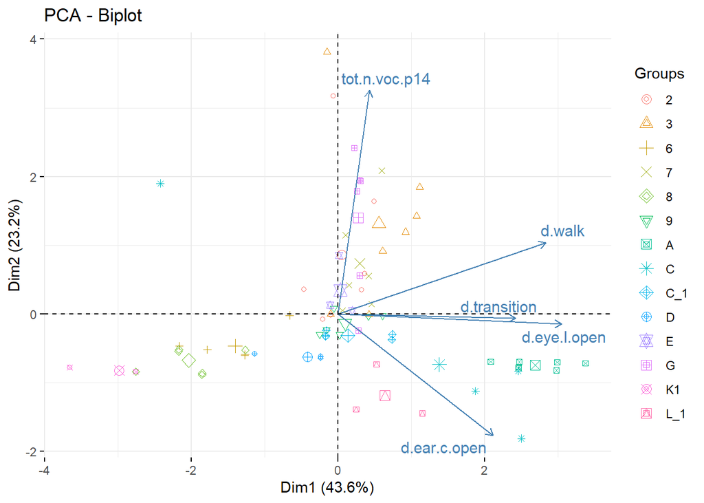

```
##
## Call:
## PCA(X = df_numeric, scale.unit = TRUE, graph = FALSE)
##
##
## Eigenvalues
##                        Dim.1   Dim.2   Dim.3   Dim.4   Dim.5
## Variance               2.182   1.160   0.766   0.499   0.393
## % of var.             43.635  23.195  15.329   9.980   7.861
## Cumulative % of var.  43.635  66.830  82.159  92.139 100.000
##
## Individuals (the 10 first)
##                   Dist    Dim.1    ctr   cos2    Dim.2    ctr   cos2    Dim.3
## 1             |  2.059 |  0.290  0.049  0.020 |  1.952  4.212  0.899 |  0.120
## 2             |  2.755 |  0.218  0.028  0.006 |  2.418  6.465  0.770 |  0.298
## 3             |  2.063 |  0.308  0.056  0.022 |  1.934  4.136  0.879 |  0.111
## 4             |  0.729 |  0.294  0.051  0.162 |  0.560  0.346  0.589 |  0.012
## 5             |  1.968 |  0.258  0.039  0.017 |  1.789  3.538  0.826 |  0.087
## 6             |  0.734 |  0.275  0.044  0.141 | -0.240  0.064  0.107 | -0.387
## 7             |  3.697 |  3.374  6.690  0.833 | -0.718  0.570  0.038 | -0.003
## 8             |  2.587 |  2.461  3.558  0.905 | -0.789  0.688  0.093 | -0.087
## 9             |  2.568 |  2.470  3.584  0.925 | -0.697  0.538  0.074 | -0.057
## 10            |  3.258 |  2.976  5.206  0.835 | -0.821  0.745  0.063 | -0.932
##                  ctr   cos2
## 1              0.024  0.003 |
## 2              0.149  0.012 |
## 3              0.021  0.003 |
## 4              0.000  0.000 |
## 5              0.013  0.002 |
## 6              0.251  0.279 |
## 7              0.000  0.000 |
## 8              0.013  0.001 |
## 9              0.006  0.001 |
## 10             1.453  0.082 |
##
## Variables
##                  Dim.1    ctr   cos2    Dim.2    ctr   cos2    Dim.3    ctr
## d.ear.c.open  |  0.592 16.052  0.350 | -0.494 21.080  0.244 |  0.520 35.344
## d.eye.l.open  |  0.854 33.399  0.729 | -0.041  0.147  0.002 |  0.024  0.073
## d.transition  |  0.678 21.053  0.459 | -0.018  0.027  0.000 | -0.654 55.757
## d.walk        |  0.793 28.834  0.629 |  0.291  7.288  0.085 |  0.109  1.550
## tot.n.voc.p14 |  0.120  0.661  0.014 |  0.910 71.458  0.829 |  0.236  7.276
##                 cos2
## d.ear.c.open   0.271 |
## d.eye.l.open   0.001 |
## d.transition   0.427 |
## d.walk         0.012 |
## tot.n.voc.p14  0.056 |
```

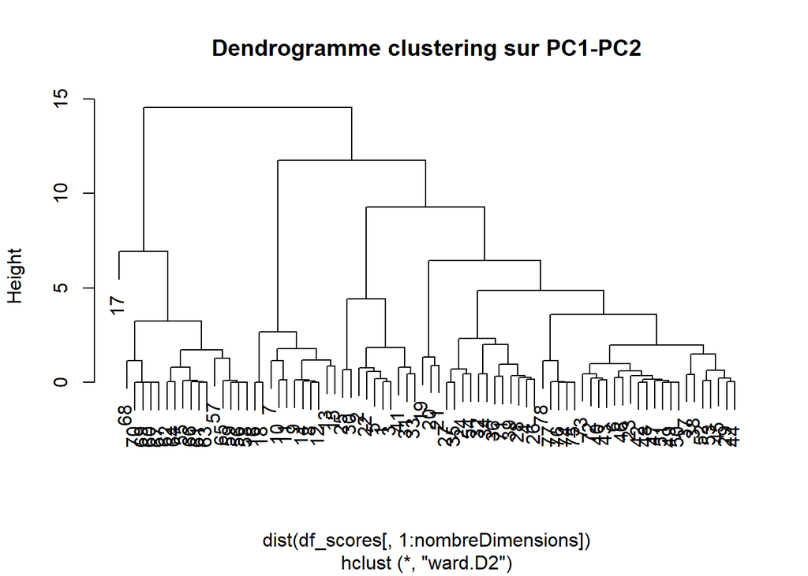

```
## Clustering automatique avec cutreeDynamic()
```

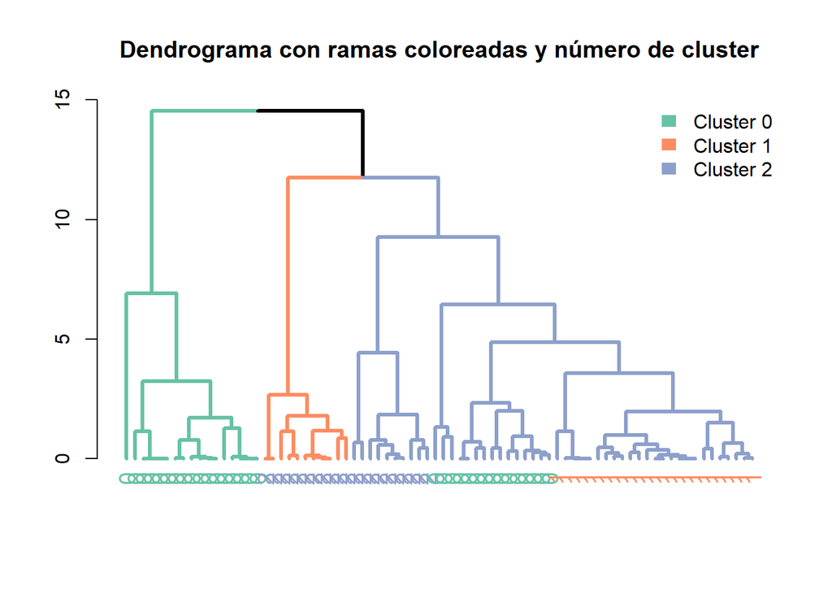

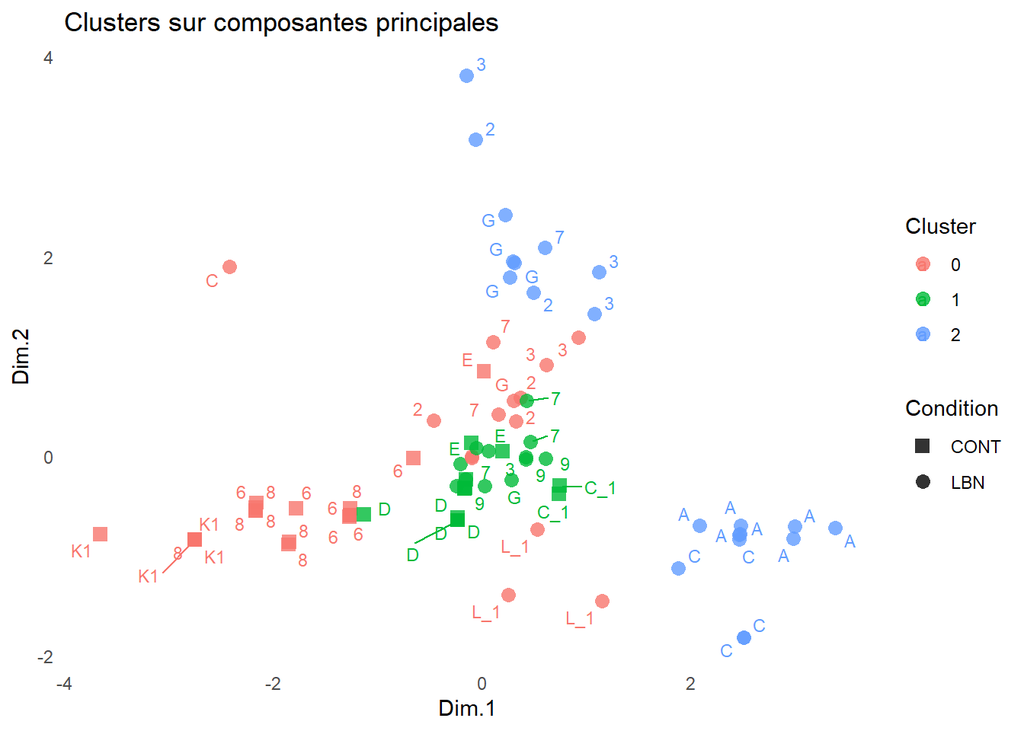

```
## # A tibble: 15 × 6
## # Groups:   CageID [14]
##    CageID cluster nb_obs total_obs prop_cluster Condition
##    <fct>  <fct>    <int>     <int>        <dbl> <fct>
##  1 6      0            6         6        1     CONT
##  2 8      0            7         7        1     CONT
##  3 K1     0            4         4        1     CONT
##  4 L_1    0            3         3        1     LBN
##  5 2      0            4         7        0.571 LBN
##  6 3      0            3         7        0.429 LBN
##  7 9      1            6         6        1     LBN
##  8 C_1    1            6         6        1     CONT
##  9 D      1            5         5        1     CONT
## 10 E      1            2         3        0.667 CONT
## 11 7      1            3         6        0.5   LBN
## 12 A      2            7         7        1     LBN
## 13 C      2            4         5        0.8   LBN
## 14 G      2            4         6        0.667 LBN
## 15 3      2            3         7        0.429 LBN
```